# Chulwalhar Flower Exports: Time Series Data Modeling and Forecasting

July 24, 2016

# Introduction

Chulwalhar, part an of island group in the northern hemisphere, is known for the winter-blooming plants. They export Efak, Wuge, and Etel with known increases in exports toward end of year. We will be performing exploratory data analysis and determining the best forecasting model along this time series data. Some important points to note are that Chulwalhar celebrates independence on December 1st and the March equinox, so we will be evaluating these observations moving through our analysis. We will be determining which are influencing indicators for Prime Minister of Chulwalhar, who is the orignator of this request.

## Project Setup and Required Packages

```r
setwd("C:/Users/thisi/OneDrive/git_repositories/CaseStudy10_LeeMessaGarza")
library(fpp) # must install.packages("fpp", repos = "https://cran.revolutionanalytics.com")
library(foreach) # must install.packages("foreach", repos = "https://cran.revolutionanalytics.com")
```

## Import and Data Cleanup

```r
source("ImportAndCleanupData.R")
```

Importing and tidying data from the files: ImportedAsIsDataChulwalar.csv, ImportedPlanDataChulwalar.csv, and ImportedIndicatorsChulwalar.csv.

## Defined Objects

```r
source("DefinedObjects.R")
```

All Objects loaded for exploration and analysis

# Exploration of Chulwalar Data

## Definition of the Indicators and Their Correlation with the Basic Data

### Monthly Change in Export Price Index (CEPI)

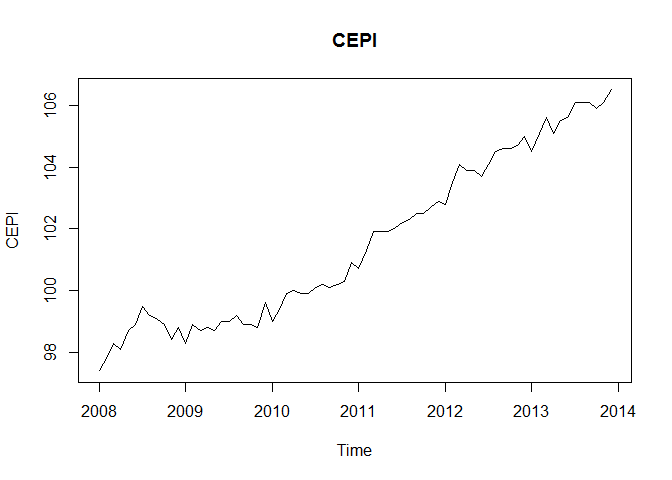

```r
plot(CEPI, main="CEPI")
```

```r
cor(TotalAsIs, CEPI)
```

```
## [1] 0.663925
```

```r
cor(EfakAsIs , CEPI)
```

```
## [1] 0.9303543
```

```r
cor(WugeAsIs, CEPI)
```

```
## [1] 0.7618551
```

```r
cor(TotalEtelAsIs, CEPI)
```

```
## [1] 0.339713
```

```r
cor(BlueEtelAsIs , CEPI)
```

```
## [1] 0.1448837
```

```r
cor(RedEtelAsIs , CEPI)
```

```
## [1] 0.3587646
```

The CEPI correlates very well with the efak exports.

### Monthly Satisfaction Index (SI) government based data

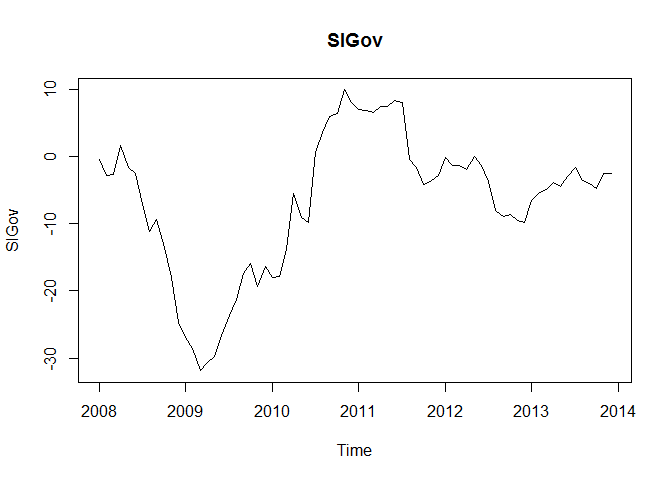

```r
plot(SIGov, main="SIGov")
```

```r
cor(TotalAsIs, SIGov)
```

```
## [1] 0.2007768
```

```r
cor(EfakAsIs , SIGov)
```

```
## [1] 0.37934
```

```r
cor(WugeAsIs, SIGov)
```

```
## [1] 0.3030266
```

```r
cor(TotalEtelAsIs, SIGov)
```

```
## [1] 0.002556094
```

```r
cor(BlueEtelAsIs , SIGov)
```

```
## [1] -0.04146932
```

```r
cor(RedEtelAsIs , SIGov)
```

```
## [1] 0.009978415
```

The Satisfaction Index does not show any particular correlation with any of the exports data.

### Average monthly temperatures in Chulwalar

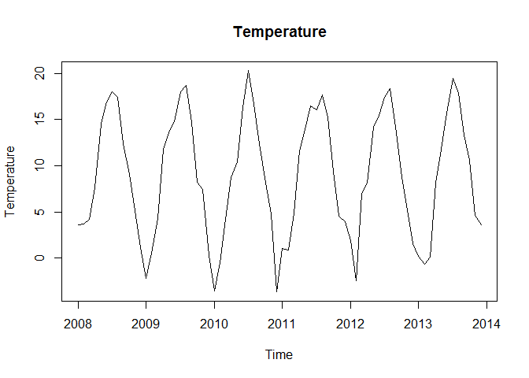

```r
plot(Temperature, main="Temperature")
```

```r
cor(TotalAsIs, Temperature)
```

```
## [1] -0.3429684
```

```r
cor(EfakAsIs , Temperature)
```

```
## [1] -0.07951179
```

```r
cor(WugeAsIs, Temperature)
```

```
## [1] -0.2045082
```

```r
cor(TotalEtelAsIs, Temperature)
```

```
## [1] -0.453138
```

```r
cor(BlueEtelAsIs , Temperature)
```

```
## [1] -0.6356067
```

```r
cor(RedEtelAsIs , Temperature)
```

```
## [1] -0.4028941
```

The temperatures have a negative correlation, exports increase in the colder months. However, the relationship is only stronger with blue Etels.

### Monthly births in Chulwalar

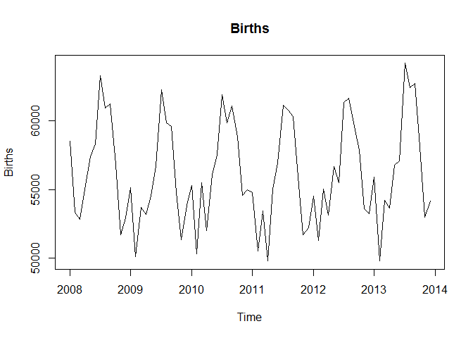

```r
plot(Births, main="Births")
```

```r
cor(TotalAsIs, Births)
```

```
## [1] -0.1190228
```

```r
cor(EfakAsIs , Births)
```

```
## [1] -0.05802961
```

```r
cor(WugeAsIs, Births)
```

```
## [1] -0.007371339
```

```r
cor(TotalEtelAsIs, Births)
```

```
## [1] -0.1504242
```

```r
cor(BlueEtelAsIs , Births)
```

```
## [1] -0.2812913
```

```r
cor(RedEtelAsIs , Births)
```

```
## [1] -0.1217222
```

The consideration by Chulwalar’s experts was that expecting new parents to try to export more products to pay for the cost of a new child. However, this could not be confirmed.

### Monthly Satisfaction Index (SI) external index

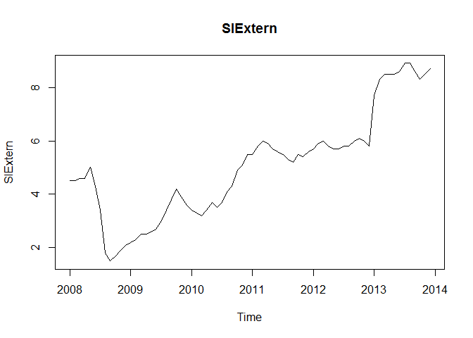

```r
plot(SIExtern, main="SIExtern")
```

```r
cor(TotalAsIs, SIExtern)
```

```
## [1] 0.5883122
```

```r
cor(EfakAsIs , SIExtern)
```

```
## [1] 0.8358147
```

```r
cor(WugeAsIs, SIExtern)
```

```
## [1] 0.6786552
```

```r
cor(TotalEtelAsIs, SIExtern)
```

```
## [1] 0.2865672
```

```r
cor(BlueEtelAsIs , SIExtern)
```

```
## [1] 0.1604768
```

```r
cor(RedEtelAsIs , SIExtern)
```

```
## [1] 0.2960946
```

This indicator also has a high correlation with Efak exports.

### Yearly Exports from Urbano

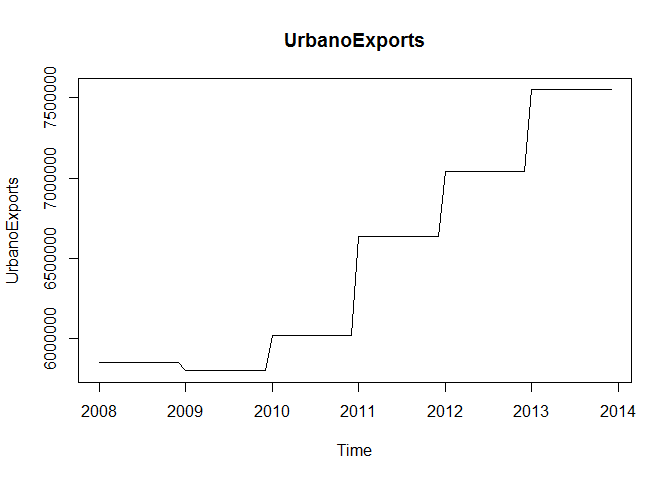

```r
plot(UrbanoExports, main="UrbanoExports")
```

```r
cor(TotalAsIs, UrbanoExports)
```

```
## [1] 0.638178
```

```r
cor(EfakAsIs , UrbanoExports)
```

```
## [1] 0.9163565
```

```r
cor(WugeAsIs, UrbanoExports)
```

```
## [1] 0.7118468
```

```r
cor(TotalEtelAsIs, UrbanoExports)
```

```
## [1] 0.3182532
```

```r
cor(BlueEtelAsIs , UrbanoExports)
```

```
## [1] 0.1655794
```

```r
cor(RedEtelAsIs , UrbanoExports)
```

```
## [1] 0.3309962
```

This indicator also has a high correlation with Efak exports. The Wuge exports also show a correlation. Unfortunatly it was not possible to find other useful indicators based on exports from Urbano, due to possible informers being very restrictive with information.

### Yearly number of Globalisation Party members in Chulwalar

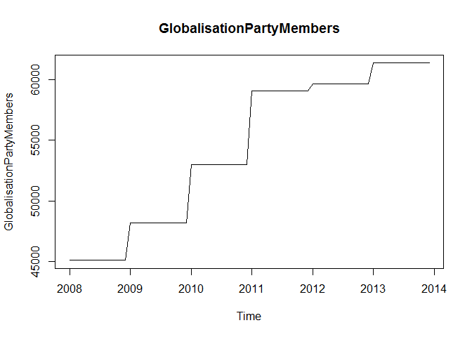

```r
plot(GlobalisationPartyMembers, main="GlobalisationPartyMembers")
```

```r
cor(TotalAsIs, GlobalisationPartyMembers)
```

```
## [1] 0.630084
```

```r
cor(EfakAsIs , GlobalisationPartyMembers)
```

```
## [1] 0.8963942
```

```r
cor(WugeAsIs, GlobalisationPartyMembers)
```

```
## [1] 0.7193864
```

```r
cor(TotalEtelAsIs, GlobalisationPartyMembers)
```

```
## [1] 0.2994635
```

```r
cor(BlueEtelAsIs , GlobalisationPartyMembers)
```

```
## [1] 0.08547266
```

```r
cor(RedEtelAsIs , GlobalisationPartyMembers)
```

```
## [1] 0.3234832
```

There is a similar picture here to that of Urbano Exports. It should however be noted that there is a continuous growth here and that the yearly view could lead to the data appearing to correlate, although this could just be due to an increase in trend. Although this could also be true for the Urbano Exports, the trend seems logical due to the Chulwalar’s exports growing in accordance with the Urbano’s Exports.

### Monthly Average Export Price Index for Chulwalar

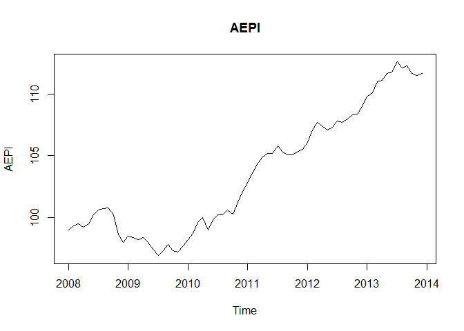

```r
plot(AEPI, main="AEPI")
```

```r
cor(TotalAsIs, AEPI)
```

```
## [1] 0.625232
```

```r
cor(EfakAsIs , AEPI)
```

```
## [1] 0.9056624
```

```r
cor(WugeAsIs, AEPI)
```

```
## [1] 0.7159733
```

```r
cor(TotalEtelAsIs, AEPI)
```

```
## [1] 0.3035506
```

```r
cor(BlueEtelAsIs , AEPI)
```

```
## [1] 0.1577964
```

```r
cor(RedEtelAsIs , AEPI)
```

```
## [1] 0.3157277
```

The continuous growth leads to a good correlation here too.

### Monthly Producer Price Index (PPI) for Etel in Chulwalar

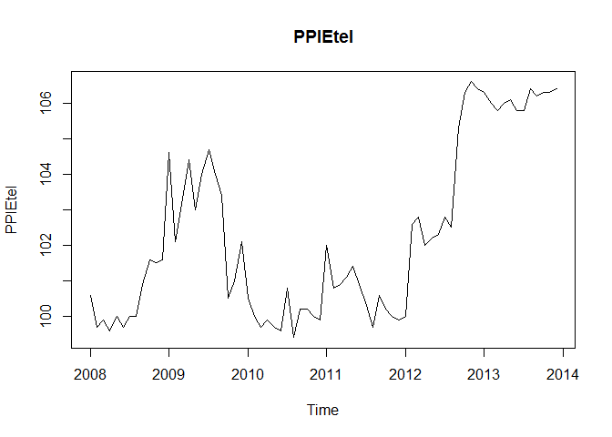

```r
plot(PPIEtel, main="PPIEtel")
```

```r
cor(TotalAsIs, PPIEtel)
```

```
## [1] 0.4836129
```

```r
cor(EfakAsIs , PPIEtel)
```

```
## [1] 0.5865375
```

```r
cor(WugeAsIs, PPIEtel)
```

```
## [1] 0.4920865
```

```r
cor(TotalEtelAsIs, PPIEtel)
```

```
## [1] 0.3374707
```

```r
cor(BlueEtelAsIs , PPIEtel)
```

```
## [1] 0.2445472
```

```r
cor(RedEtelAsIs , PPIEtel)
```

```
## [1] 0.3391872
```

This indicator does not give the expected results. It does not show any correlation worth mentioning, not even with the Etel segment.

### National Holidays

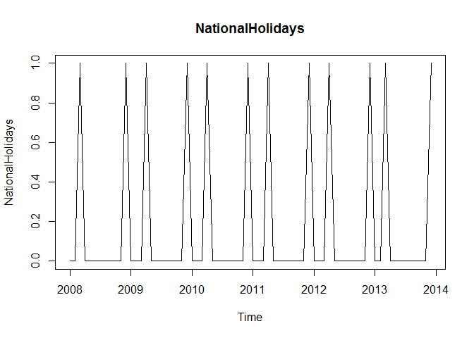

```r
plot(NationalHolidays, main="NationalHolidays")
```

```r
cor(TotalAsIs, NationalHolidays)
```

```
## [1] -0.007883708
```

```r
cor(EfakAsIs , NationalHolidays)
```

```
## [1] 0.001235706
```

```r
cor(WugeAsIs, NationalHolidays)
```

```
## [1] 0.06505569
```

```r
cor(TotalEtelAsIs, NationalHolidays)
```

```
## [1] -0.01081446
```

```r
cor(BlueEtelAsIs , NationalHolidays)
```

```
## [1] 0.02903763
```

```r
cor(RedEtelAsIs , NationalHolidays)
```

```
## [1] -0.01717636
```

The months April and December do not correlate well with the exports data. However later tests will show that these are worth considering. The missing correlation is just due to the sparse structure of the NationalHolidays time series.

### Chulwalar Index (Total value of all companies in Chulwalar)

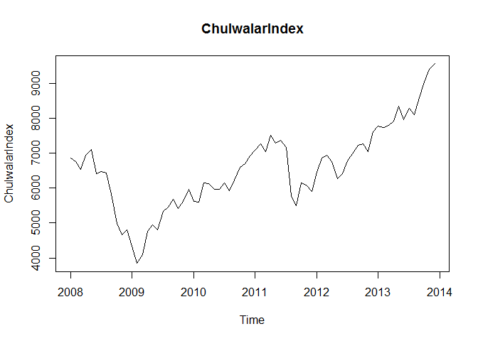

```r
plot(ChulwalarIndex, main="ChulwalarIndex")
```

```r
cor(TotalAsIs, ChulwalarIndex)
```

```
## [1] 0.4837017
```

```r
cor(EfakAsIs , ChulwalarIndex)
```

```
## [1] 0.7129557
```

```r
cor(WugeAsIs, ChulwalarIndex)
```

```
## [1] 0.5721568
```

```r
cor(TotalEtelAsIs, ChulwalarIndex)
```

```
## [1] 0.2209171
```

```r
cor(BlueEtelAsIs , ChulwalarIndex)
```

```
## [1] 0.1469233
```

```r
cor(RedEtelAsIs , ChulwalarIndex)
```

```
## [1] 0.2242922
```

No particular findings.

### Monthly Inflation rate in Chulwalar

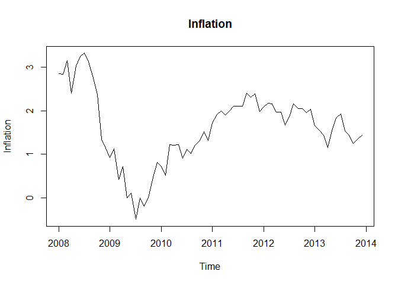

```r
plot(Inflation, main="Inflation")
```

```r
cor(TotalAsIs, Inflation)
```

```
## [1] 0.002438708
```

```r
cor(EfakAsIs , Inflation)
```

```
## [1] 0.1454134
```

```r
cor(WugeAsIs, Inflation)
```

```
## [1] 0.03191332
```

```r
cor(TotalEtelAsIs, Inflation)
```

```
## [1] -0.08378282
```

```r
cor(BlueEtelAsIs , Inflation)
```

```
## [1] 0.02117817
```

```r
cor(RedEtelAsIs , Inflation)
```

```
## [1] -0.0982151
```

No particular findings.

### Proposed spending for National Holidays

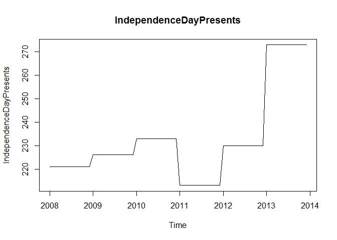

```r
plot(IndependenceDayPresents, main="IndependenceDayPresents")
```

```r
cor(TotalAsIs, IndependenceDayPresents)
```

```
## [1] 0.4359522
```

```r
cor(EfakAsIs , IndependenceDayPresents)
```

```
## [1] 0.5243145
```

```r
cor(WugeAsIs, IndependenceDayPresents)
```

```
## [1] 0.4892437
```

```r
cor(TotalEtelAsIs, IndependenceDayPresents)
```

```
## [1] 0.2872013
```

```r
cor(BlueEtelAsIs , IndependenceDayPresents)
```

```
## [1] 0.2110373
```

```r
cor(RedEtelAsIs , IndependenceDayPresents)
```

```
## [1] 0.2881631
```

No particular findings.

### Influence of National Holiday

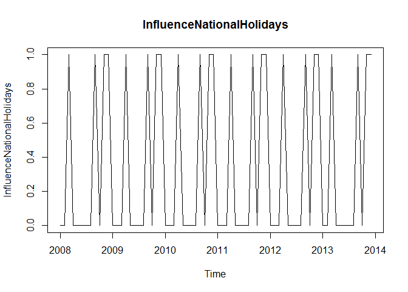

```r
plot(InfluenceNationalHolidays, main="InfluenceNationalHolidays")
```

```r
cor(TotalAsIs, InfluenceNationalHolidays)
```

```
## [1] 0.3717463
```

```r
cor(EfakAsIs , InfluenceNationalHolidays)
```

```
## [1] 0.09926836
```

```r
cor(WugeAsIs, InfluenceNationalHolidays)
```

```
## [1] 0.3712288
```

```r
cor(TotalEtelAsIs, InfluenceNationalHolidays)
```

```
## [1] 0.4535836
```

```r
cor(BlueEtelAsIs , InfluenceNationalHolidays)
```

```
## [1] 0.2792198
```

```r
cor(RedEtelAsIs , InfluenceNationalHolidays)
```

```
## [1] 0.4643512
```

This indicator is an experiment where the influence of National Holidays is extended into the months leading up to the holiday. However later tests show that this indicator is no better for forecasting than the orignial National Holidays indicator.

## Correlation of the indicators with each another

```r
IndicatorsmatrixStandardised
```

Establish the standardised data matrix

```r
NumberOfIndicators
```

```
## [1] 72
```

The dimensions of the matrix are determined by the number of indicators.

```r
IndicatorsCorrelationCoefficientMatrix
```

```
##                                 CEPIVector SIGovVector TemperatureVector
## CEPIVector                      1.00000000  0.38443508       0.061196862
## SIGovVector                     0.38443508  1.00000000       0.088109231
## TemperatureVector               0.06119686  0.08810923       1.000000000
## BirthsVector                    0.08872676  0.12753378       0.744270853
## SIGovVector                     0.38443508  1.00000000       0.088109231
## UrbanoExportsVector             0.97660022  0.40700264      -0.001244458
## GlobalisationPartyMembersVector 0.91557949  0.49433954      -0.009695828
## AEPIVector                      0.97697428  0.45955807       0.055196145
## PPIEtel                         0.65446147 -0.23602751      -0.013959906
## NationalHolidaysVector          0.04830482 -0.02025819      -0.316148237
## ChulwalarIndexVector            0.76208613  0.63652935       0.036317166
## InflationVector                 0.16379793  0.55866085       0.054966975
## IndependenceDayPresentsVector   0.64887003  0.03237405      -0.040110690
##                                 BirthsVector SIGovVector
## CEPIVector                        0.08872676  0.38443508
## SIGovVector                       0.12753378  1.00000000
## TemperatureVector                 0.74427085  0.08810923
## BirthsVector                      1.00000000  0.12753378
## SIGovVector                       0.12753378  1.00000000
## UrbanoExportsVector               0.03139251  0.40700264
## GlobalisationPartyMembersVector  -0.01768274  0.49433954
## AEPIVector                        0.09673808  0.45955807
## PPIEtel                           0.05960084 -0.23602751
## NationalHolidaysVector           -0.37785553 -0.02025819
## ChulwalarIndexVector              0.11795545  0.63652935
## InflationVector                   0.11231574  0.55866085
## IndependenceDayPresentsVector     0.10063892  0.03237405
##                                 UrbanoExportsVector
## CEPIVector                             9.766002e-01
## SIGovVector                            4.070026e-01
## TemperatureVector                     -1.244458e-03
## BirthsVector                           3.139251e-02
## SIGovVector                            4.070026e-01
## UrbanoExportsVector                    1.000000e+00
## GlobalisationPartyMembersVector        9.121013e-01
## AEPIVector                             9.827920e-01
## PPIEtel                                6.521194e-01
## NationalHolidaysVector                -1.876433e-17
## ChulwalarIndexVector                   7.856783e-01
```

[output cut: 43 more lines]

```
## IndependenceDayPresentsVector             0.62615921    -0.185842679
##                                 IndependenceDayPresentsVector
## CEPIVector                                         0.64887003
## SIGovVector                                        0.03237405
## TemperatureVector                                 -0.04011069
## BirthsVector                                       0.10063892
## SIGovVector                                        0.03237405
## UrbanoExportsVector                                0.66999963
## GlobalisationPartyMembersVector                    0.46063633
## AEPIVector                                         0.64313387
## PPIEtel                                            0.71474813
## NationalHolidaysVector                             0.00000000
## ChulwalarIndexVector                               0.62615921
## InflationVector                                   -0.18584268
## IndependenceDayPresentsVector                      1.00000000
```

Produce the IndicatorsCorrelationCoefficientMatrix.

## ModelWithAlllIndicators and With Each Indicator Individually

### All Indiators in one model:

```r
summary(ModelWithAlllIndicators)
```

```
##
## Call:
## tslm(formula = TotalAsIs ~ trend + season + CEPI + SIGov + Temperature +
##     Births + SIExtern + UrbanoExports + GlobalisationPartyMembers +
##     AEPI + PPIEtel + NationalHolidays + ChulwalarIndex + Inflation +
##     IndependenceDayPresents)
##
## Residuals:
##     Min      1Q  Median      3Q     Max
## -458389 -119426    1119  165463  342741
##
## Coefficients:
##                             Estimate Std. Error t value Pr(>|t|)
## (Intercept)               -8.982e+05  2.301e+07  -0.039  0.96904
## trend                      3.176e+03  3.849e+04   0.083  0.93458
## season2                    3.146e+05  2.678e+05   1.175  0.24624
## season3                    5.172e+05  2.649e+05   1.953  0.05695 .
## season4                    2.972e+05  3.413e+05   0.871  0.38836
## season5                   -7.277e+04  3.661e+05  -0.199  0.84333
## season6                   -2.597e+05  4.199e+05  -0.618  0.53932
## season7                   -7.550e+05  5.225e+05  -1.445  0.15525
## season8                   -2.869e+05  4.990e+05  -0.575  0.56809
## season9                    1.066e+06  4.225e+05   2.523  0.01517 *
## season10                   8.033e+05  3.352e+05   2.396  0.02068 *
## season11                   1.226e+06  3.555e+05   3.449  0.00122 **
## season12                   9.734e+05  3.645e+05   2.670  0.01044 *
## CEPI                      -3.551e+04  2.516e+05  -0.141  0.88838
## SIGov                     -1.506e+04  9.150e+03  -1.646  0.10657
## Temperature               -3.108e+04  2.069e+04  -1.502  0.14003
## Births                     8.045e+01  3.894e+01   2.066  0.04448 *
## SIExtern                   3.706e+04  5.872e+04   0.631  0.53109
## UrbanoExports              5.323e-01  5.675e-01   0.938  0.35317
## GlobalisationPartyMembers  7.324e+01  6.583e+01   1.113  0.27163
## AEPI                      -6.003e+04  7.476e+04  -0.803  0.42612
## PPIEtel                    7.799e+03  3.622e+04   0.215  0.83048
## NationalHolidays          -3.192e+05  1.718e+05  -1.858  0.06963 .
## ChulwalarIndex             6.102e+01  7.545e+01   0.809  0.42284
## Inflation                  7.058e+04  1.555e+05   0.454  0.65213
## IndependenceDayPresents    4.211e+01  6.187e+03   0.007  0.99460
## ---
## Signif. codes:  0 '***' 0.001 '**' 0.01 '*' 0.05 '.' 0.1 ' ' 1
##
## Residual standard error: 249400 on 46 degrees of freedom
## Multiple R-squared:  0.9421, Adjusted R-squared:  0.9106
## F-statistic: 29.94 on 25 and 46 DF,  p-value: < 2.2e-16
```

### CEPI:

```r
summary(ModelWithCEPI)
```

```
##
## Call:
## tslm(formula = TotalAsIs ~ trend + season + CEPI)
##
## Residuals:
##     Min      1Q  Median      3Q     Max
## -670684 -142117    7024  168664  495366
##
## Coefficients:
##             Estimate Std. Error t value Pr(>|t|)
## (Intercept) -2946424    5153463  -0.572 0.569710
## trend          19698       6926   2.844 0.006145 **
## season2      -153665     153683  -1.000 0.321523
## season3         8677     156732   0.055 0.956039
## season4      -634082     154130  -4.114 0.000124 ***
## season5      -648875     154240  -4.207 9.09e-05 ***
## season6      -906108     153943  -5.886 2.10e-07 ***
## season7     -1112258     155872  -7.136 1.73e-09 ***
## season8      -755527     155490  -4.859 9.34e-06 ***
## season9       683382     154129   4.434 4.18e-05 ***
## season10      287071     153168   1.874 0.065940 .
## season11      465878     152885   3.047 0.003474 **
## season12       50523     154712   0.327 0.745176
## CEPI           53135      53376   0.995 0.323636
## ---
## Signif. codes:  0 '***' 0.001 '**' 0.01 '*' 0.05 '.' 0.1 ' ' 1
##
## Residual standard error: 263300 on 58 degrees of freedom
## Multiple R-squared:  0.9187, Adjusted R-squared:  0.9004
## F-statistic: 50.39 on 13 and 58 DF,  p-value: < 2.2e-16
```

The CEPI Indicator correlated best with total exports. Indeed the multiple R² improved the model slighltly compared to the simple ModelWithTrendAndSeasonalityOnly. However, the adjusted R² remains the same.

### SIGov:

```r
summary(ModelWithSIGov)
```

```
##
## Call:
## tslm(formula = TotalAsIs ~ trend + season + SIGov)
##
## Residuals:
##     Min      1Q  Median      3Q     Max
## -697126 -157160   22782  161382  486711
##
## Coefficients:
##             Estimate Std. Error t value Pr(>|t|)
## (Intercept)  2154993     126151  17.083  < 2e-16 ***
## trend          26826       1656  16.196  < 2e-16 ***
## season2      -133003     152843  -0.870 0.387782
## season3        44751     152866   0.293 0.770763
## season4      -606128     152952  -3.963 0.000205 ***
## season5      -622634     152935  -4.071 0.000143 ***
## season6      -881666     153013  -5.762 3.35e-07 ***
## season7     -1075681     153183  -7.022 2.69e-09 ***
## season8      -726089     153194  -4.740 1.43e-05 ***
## season9       705690     153291   4.604 2.31e-05 ***
## season10      297924     153457   1.941 0.057071 .
## season11      468770     153659   3.051 0.003439 **
## season12       68494     153977   0.445 0.658095
## SIGov          -2003       3274  -0.612 0.543174
## ---
## Signif. codes:  0 '***' 0.001 '**' 0.01 '*' 0.05 '.' 0.1 ' ' 1
##
## Residual standard error: 264700 on 58 degrees of freedom
## Multiple R-squared:  0.9178, Adjusted R-squared:  0.8994
## F-statistic: 49.81 on 13 and 58 DF,  p-value: < 2.2e-16
```

The Satisfaction Index (gov) hardly changes the function of the model.

### Temperature:

```r
summary(ModelWithTemperature)
```

```
##
## Call:
## tslm(formula = TotalAsIs ~ trend + season + Temperature)
##
## Residuals:
##     Min      1Q  Median      3Q     Max
## -706803 -154965   23511  160215  483373
##
## Coefficients:
##             Estimate Std. Error t value Pr(>|t|)
## (Intercept)  2185999     118102  18.509  < 2e-16 ***
## trend          26367       1526  17.278  < 2e-16 ***
## season2      -130163     152875  -0.851  0.39803
## season3        91513     171443   0.534  0.59553
## season4      -504879     236159  -2.138  0.03675 *
## season5      -476774     296010  -1.611  0.11268
## season6      -703539     345717  -2.035  0.04643 *
## season7      -873818     386156  -2.263  0.02740 *
## season8      -524053     378812  -1.383  0.17184
## season9       858772     305542   2.811  0.00673 **
## season10      401142     232466   1.726  0.08974 .
## season11      530742     183985   2.885  0.00549 **
## season12       85552     155077   0.552  0.58329
## Temperature   -11344      19587  -0.579  0.56473
## ---
## Signif. codes:  0 '***' 0.001 '**' 0.01 '*' 0.05 '.' 0.1 ' ' 1
##
## Residual standard error: 264800 on 58 degrees of freedom
## Multiple R-squared:  0.9177, Adjusted R-squared:  0.8993
## F-statistic: 49.78 on 13 and 58 DF,  p-value: < 2.2e-16
```

### Births:

```r
summary(ModelWithBirths)
```

```
##
## Call:
## tslm(formula = TotalAsIs ~ trend + season + Births)
##
## Residuals:
##     Min      1Q  Median      3Q     Max
## -648252 -106586   23124  166173  443675
##
## Coefficients:
##               Estimate Std. Error t value Pr(>|t|)
## (Intercept) -1.485e+06  1.452e+06  -1.023 0.310779
## trend        2.633e+04  1.449e+03  18.163  < 2e-16 ***
## season2      1.856e+05  1.918e+05   0.968 0.337199
## season3      1.510e+05  1.512e+05   0.998 0.322286
## season4     -4.181e+05  1.639e+05  -2.551 0.013402 *
## season5     -6.484e+05  1.459e+05  -4.444 4.04e-05 ***
## season6     -9.698e+05  1.496e+05  -6.482 2.16e-08 ***
## season7     -1.518e+06  2.265e+05  -6.704 9.20e-09 ***
## season8     -1.068e+06  1.992e+05  -5.364 1.48e-06 ***
## season9      3.721e+05  1.966e+05   1.893 0.063345 .
## season10     2.114e+05  1.502e+05   1.407 0.164622
## season11     6.744e+05  1.666e+05   4.049 0.000155 ***
## season12     2.147e+05  1.565e+05   1.372 0.175458
## Births       6.589e+01  2.601e+01   2.533 0.014026 *
## ---
## Signif. codes:  0 '***' 0.001 '**' 0.01 '*' 0.05 '.' 0.1 ' ' 1
##
## Residual standard error: 251900 on 58 degrees of freedom
## Multiple R-squared:  0.9255, Adjusted R-squared:  0.9088
## F-statistic: 55.43 on 13 and 58 DF,  p-value: < 2.2e-16
```

### SIExtern:

```r
summary(ModelWithSIExtern)
```

```
##
## Call:
## tslm(formula = TotalAsIs ~ trend + season + SIExtern)
##
## Residuals:
##     Min      1Q  Median      3Q     Max
## -667444 -154044   -5891  162628  473612
##
## Coefficients:
##             Estimate Std. Error t value Pr(>|t|)
## (Intercept)  2124425     137869  15.409  < 2e-16 ***
## trend          24163       3191   7.572 3.20e-10 ***
## season2      -133767     152487  -0.877 0.383979
## season3        43156     152535   0.283 0.778243
## season4      -609825     152516  -3.998 0.000183 ***
## season5      -624208     152569  -4.091 0.000134 ***
## season6      -877941     152767  -5.747 3.55e-07 ***
## season7     -1071287     153027  -7.001 2.92e-09 ***
## season8      -710173     153873  -4.615 2.22e-05 ***
## season9       722059     154265   4.681 1.76e-05 ***
## season10      312879     153885   2.033 0.046617 *
## season11      486780     154278   3.155 0.002542 **
## season12       88661     154442   0.574 0.568139
## SIExtern       26522      32881   0.807 0.423187
## ---
## Signif. codes:  0 '***' 0.001 '**' 0.01 '*' 0.05 '.' 0.1 ' ' 1
##
## Residual standard error: 264000 on 58 degrees of freedom
## Multiple R-squared:  0.9182, Adjusted R-squared:  0.8998
## F-statistic: 50.07 on 13 and 58 DF,  p-value: < 2.2e-16
```

### UrbanoExports:

```r
summary(ModelWithTotalUrbanoExports)
```

```
##
## Call:
## tslm(formula = TotalAsIs ~ trend + season + UrbanoExports)
##
## Residuals:
##     Min      1Q  Median      3Q     Max
## -651323 -145654    7297  172919  469753
##
## Coefficients:
##                 Estimate Std. Error t value Pr(>|t|)
## (Intercept)    1.232e+06  9.485e+05   1.299 0.199178
## trend          2.118e+04  5.414e+03   3.912 0.000243 ***
## season2       -1.259e+05  1.521e+05  -0.828 0.411030
## season3        5.708e+04  1.524e+05   0.375 0.709261
## season4       -5.934e+05  1.528e+05  -3.882 0.000267 ***
## season5       -6.025e+05  1.535e+05  -3.925 0.000232 ***
## season6       -8.568e+05  1.544e+05  -5.551 7.40e-07 ***
## season7       -1.048e+06  1.554e+05  -6.741 7.96e-09 ***
## season8       -6.879e+05  1.566e+05  -4.392 4.82e-05 ***
## season9        7.477e+05  1.580e+05   4.732 1.47e-05 ***
## season10       3.473e+05  1.596e+05   2.176 0.033640 *
## season11       5.246e+05  1.613e+05   3.252 0.001913 **
## season12       1.317e+05  1.632e+05   0.807 0.423118
## UrbanoExports  1.717e-01  1.700e-01   1.010 0.316698
## ---
## Signif. codes:  0 '***' 0.001 '**' 0.01 '*' 0.05 '.' 0.1 ' ' 1
##
## Residual standard error: 263200 on 58 degrees of freedom
## Multiple R-squared:  0.9187, Adjusted R-squared:  0.9005
## F-statistic: 50.41 on 13 and 58 DF,  p-value: < 2.2e-16
```

Indicator with adjusted R² shows a better result than the reference model (ModelWithTrendAndSeasonalityOnly). The individual months are also very significant.

### GlobalisationPartyMembers:

```r
summary(ModelWithGlobalisationPartyMembers)
```

```
##
## Call:
## tslm(formula = TotalAsIs ~ trend + season + GlobalisationPartyMembers)
##
## Residuals:
##     Min      1Q  Median      3Q     Max
## -696019 -161848   22345  172443  478347
##
## Coefficients:
##                             Estimate Std. Error t value Pr(>|t|)
## (Intercept)                2.629e+06  9.653e+05   2.724 0.008517 **
## trend                      2.928e+04  6.311e+03   4.640 2.04e-05 ***
## season2                   -1.340e+05  1.531e+05  -0.875 0.385097
## season3                    4.087e+04  1.535e+05   0.266 0.791010
## season4                   -6.177e+05  1.542e+05  -4.006 0.000178 ***
## season5                   -6.350e+05  1.551e+05  -4.094 0.000133 ***
## season6                   -8.973e+05  1.562e+05  -5.744 3.59e-07 ***
## season7                   -1.096e+06  1.576e+05  -6.955 3.49e-09 ***
## season8                   -7.447e+05  1.593e+05  -4.676 1.79e-05 ***
## season9                    6.829e+05  1.611e+05   4.238 8.18e-05 ***
## season10                   2.743e+05  1.632e+05   1.681 0.098191 .
## season11                   4.435e+05  1.655e+05   2.680 0.009573 **
## season12                   4.252e+04  1.680e+05   0.253 0.801132
## GlobalisationPartyMembers -9.840e+00  2.111e+01  -0.466 0.642806
## ---
## Signif. codes:  0 '***' 0.001 '**' 0.01 '*' 0.05 '.' 0.1 ' ' 1
##
## Residual standard error: 265000 on 58 degrees of freedom
## Multiple R-squared:  0.9176, Adjusted R-squared:  0.8991
## F-statistic: 49.67 on 13 and 58 DF,  p-value: < 2.2e-16
```

### AEPI:

```r
summary(ModelWithAEPI)
```

```
##
## Call:
## tslm(formula = TotalAsIs ~ trend + season + AEPI)
##
## Residuals:
##     Min      1Q  Median      3Q     Max
## -668980 -141696    1689  169009  482621
##
## Coefficients:
##             Estimate Std. Error t value Pr(>|t|)
## (Intercept)   839421    1642691   0.511 0.611288
## trend          23291       4116   5.658 4.95e-07 ***
## season2      -134830     152491  -0.884 0.380247
## season3        38792     152745   0.254 0.800419
## season4      -615165     152666  -4.029 0.000165 ***
## season5      -625294     152554  -4.099 0.000131 ***
## season6      -884504     152617  -5.796 2.95e-07 ***
## season7     -1082577     152748  -7.087 2.09e-09 ***
## season8      -723603     152794  -4.736 1.45e-05 ***
## season9       706895     152908   4.623 2.16e-05 ***
## season10      308319     153364   2.010 0.049049 *
## season11      485176     154001   3.150 0.002578 **
## season12       85919     154027   0.558 0.579115
## AEPI           14065      17159   0.820 0.415759
## ---
## Signif. codes:  0 '***' 0.001 '**' 0.01 '*' 0.05 '.' 0.1 ' ' 1
##
## Residual standard error: 264000 on 58 degrees of freedom
## Multiple R-squared:  0.9182, Adjusted R-squared:  0.8999
## F-statistic: 50.09 on 13 and 58 DF,  p-value: < 2.2e-16
```

### PPIEtel:

```r
summary(ModelWithPPIEtel)
```

```
##
## Call:
## tslm(formula = TotalAsIs ~ trend + season + PPIEtel)
##
## Residuals:
##     Min      1Q  Median      3Q     Max
## -670282 -185589   19856  172554  468929
##
## Coefficients:
##             Estimate Std. Error t value Pr(>|t|)
## (Intercept)   593668    1640506   0.362 0.718756
## trend          25282       1919  13.172  < 2e-16 ***
## season2      -122617     152330  -0.805 0.424141
## season3        53107     152246   0.349 0.728486
## season4      -603022     152264  -3.960 0.000207 ***
## season5      -614727     152459  -4.032 0.000163 ***
## season6      -872851     152619  -5.719 3.94e-07 ***
## season7     -1073314     152456  -7.040 2.51e-09 ***
## season8      -711389     153051  -4.648 1.98e-05 ***
## season9       707996     152568   4.641 2.03e-05 ***
## season10      307412     152867   2.011 0.048984 *
## season11      479843     153028   3.136 0.002692 **
## season12       80433     153124   0.525 0.601390
## PPIEtel        15872      16347   0.971 0.335606
## ---
## Signif. codes:  0 '***' 0.001 '**' 0.01 '*' 0.05 '.' 0.1 ' ' 1
##
## Residual standard error: 263400 on 58 degrees of freedom
## Multiple R-squared:  0.9186, Adjusted R-squared:  0.9003
## F-statistic: 50.34 on 13 and 58 DF,  p-value: < 2.2e-16
```

### NationalHolidays:

```r
summary(ModelWithNationalHolidays)
```

```
##
## Call:
## tslm(formula = TotalAsIs ~ trend + season + NationalHolidays)
##
## Residuals:
##     Min      1Q  Median      3Q     Max
## -555545 -153976       4  150487  404837
##
## Coefficients:
##                  Estimate Std. Error t value Pr(>|t|)
## (Intercept)       2182435     110867  19.685  < 2e-16 ***
## trend               26427       1431  18.465  < 2e-16 ***
## season2           -131168     143696  -0.913  0.36512
## season3            190430     152432   1.249  0.21658
## season4           -321411     176034  -1.826  0.07302 .
## season5           -623539     143803  -4.336 5.86e-05 ***
## season6           -883072     143867  -6.138 8.06e-08 ***
## season7          -1079124     143945  -7.497 4.29e-10 ***
## season8           -724693     144037  -5.031 5.02e-06 ***
## season9            705716     144144   4.896 8.18e-06 ***
## season10           300019     144265   2.080  0.04199 *
## season11           472099     144400   3.269  0.00182 **
## season12           505461     210051   2.406  0.01932 *
## NationalHolidays  -431536     152405  -2.832  0.00636 **
## ---
## Signif. codes:  0 '***' 0.001 '**' 0.01 '*' 0.05 '.' 0.1 ' ' 1
##
## Residual standard error: 248900 on 58 degrees of freedom
## Multiple R-squared:  0.9273, Adjusted R-squared:  0.911
## F-statistic: 56.92 on 13 and 58 DF,  p-value: < 2.2e-16
```

### ChulwalarIndex:

```r
summary(ModelWithChulwalarIndex)
```

```
##
## Call:
## tslm(formula = TotalAsIs ~ trend + season + ChulwalarIndex)
##
## Residuals:
##     Min      1Q  Median      3Q     Max
## -689635 -153608    9444  166039  495113
##
## Coefficients:
##                  Estimate Std. Error t value Pr(>|t|)
## (Intercept)     2.013e+06  2.262e+05   8.898 1.96e-12 ***
## trend           2.506e+04  2.176e+03  11.515  < 2e-16 ***
## season2        -1.295e+05  1.523e+05  -0.850 0.398630
## season3         4.684e+04  1.523e+05   0.308 0.759534
## season4        -6.157e+05  1.525e+05  -4.036 0.000161 ***
## season5        -6.281e+05  1.525e+05  -4.119 0.000122 ***
## season6        -8.809e+05  1.525e+05  -5.776 3.18e-07 ***
## season7        -1.082e+06  1.526e+05  -7.092 2.05e-09 ***
## season8        -7.182e+05  1.528e+05  -4.699 1.65e-05 ***
## season9         7.115e+05  1.529e+05   4.653 1.95e-05 ***
## season10        3.049e+05  1.530e+05   1.993 0.050965 .
## season11        4.779e+05  1.532e+05   3.120 0.002817 **
## season12        7.433e+04  1.532e+05   0.485 0.629364
## ChulwalarIndex  3.339e+01  3.805e+01   0.878 0.383723
## ---
## Signif. codes:  0 '***' 0.001 '**' 0.01 '*' 0.05 '.' 0.1 ' ' 1
##
## Residual standard error: 263800 on 58 degrees of freedom
## Multiple R-squared:  0.9184, Adjusted R-squared:  0.9001
## F-statistic: 50.18 on 13 and 58 DF,  p-value: < 2.2e-16
```

### Inflation:

```r
summary(ModelWithInflation)
```

```
##
## Call:
## tslm(formula = TotalAsIs ~ trend + season + Inflation)
##
## Residuals:
##     Min      1Q  Median      3Q     Max
## -694867 -148205    9248  156635  501218
##
## Coefficients:
##             Estimate Std. Error t value Pr(>|t|)
## (Intercept)  2160745     132862  16.263  < 2e-16 ***
## trend          26414       1526  17.313  < 2e-16 ***
## season2      -131511     153141  -0.859 0.394009
## season3        45633     153184   0.298 0.766848
## season4      -607707     153249  -3.966 0.000204 ***
## season5      -623065     153258  -4.065 0.000146 ***
## season6      -882807     153322  -5.758 3.41e-07 ***
## season7     -1078758     153407  -7.032 2.59e-09 ***
## season8      -724536     153503  -4.720 1.53e-05 ***
## season9       706375     153627   4.598 2.36e-05 ***
## season10      301603     153808   1.961 0.054698 .
## season11      474428     154026   3.080 0.003160 **
## season12       76824     154261   0.498 0.620359
## Inflation      13335      37358   0.357 0.722422
## ---
## Signif. codes:  0 '***' 0.001 '**' 0.01 '*' 0.05 '.' 0.1 ' ' 1
##
## Residual standard error: 265200 on 58 degrees of freedom
## Multiple R-squared:  0.9174, Adjusted R-squared:  0.8989
## F-statistic: 49.58 on 13 and 58 DF,  p-value: < 2.2e-16
```

### IndependenceDayPresents:

```r
summary(ModelWithIndependenceDayPresents)
```

```
##
## Call:
## tslm(formula = TotalAsIs ~ trend + season + IndependenceDayPresents)
##
## Residuals:
##     Min      1Q  Median      3Q     Max
## -704113 -161955   23265  169241  468613
##
## Coefficients:
##                         Estimate Std. Error t value Pr(>|t|)
## (Intercept)              1925395     469903   4.097 0.000131 ***
## trend                      25706       1986  12.944  < 2e-16 ***
## season2                  -130448     152891  -0.853 0.397053
## season3                    48026     152930   0.314 0.754620
## season4                  -606940     152994  -3.967 0.000203 ***
## season5                  -620657     153084  -4.054 0.000152 ***
## season6                  -879470     153200  -5.741 3.63e-07 ***
## season7                 -1074801     153342  -7.009 2.83e-09 ***
## season8                  -719650     153509  -4.688 1.72e-05 ***
## season9                   711480     153702   4.629 2.12e-05 ***
## season10                  306503     153919   1.991 0.051162 .
## season11                  479303     154163   3.109 0.002907 **
## season12                   81850     154431   0.530 0.598127
## IndependenceDayPresents     1201       2125   0.565 0.574184
## ---
## Signif. codes:  0 '***' 0.001 '**' 0.01 '*' 0.05 '.' 0.1 ' ' 1
##
## Residual standard error: 264800 on 58 degrees of freedom
## Multiple R-squared:  0.9177, Adjusted R-squared:  0.8993
## F-statistic: 49.76 on 13 and 58 DF,  p-value: < 2.2e-16
```

### InfluenceNationalHolidays:

```r
summary(ModelWithInfluenceNationalHolidays)
```

```
##
## Call:
## tslm(formula = TotalAsIs ~ trend + season + InfluenceNationalHolidays)
##
## Residuals:
##     Min      1Q  Median      3Q     Max
## -555545 -153976       4  150487  404837
##
## Coefficients:
##                           Estimate Std. Error t value Pr(>|t|)
## (Intercept)                2182435     110867  19.685  < 2e-16 ***
## trend                        26427       1431  18.465  < 2e-16 ***
## season2                    -131168     143696  -0.913  0.36512
## season3                     190430     152432   1.249  0.21658
## season4                    -321411     176034  -1.826  0.07302 .
## season5                    -623539     143803  -4.336 5.86e-05 ***
## season6                    -883072     143867  -6.138 8.06e-08 ***
## season7                   -1079124     143945  -7.497 4.29e-10 ***
## season8                    -724693     144037  -5.031 5.02e-06 ***
## season9                    1137252     209773   5.421 1.20e-06 ***
## season10                    300019     144265   2.080  0.04199 *
## season11                    903635     209949   4.304 6.53e-05 ***
## season12                    505461     210051   2.406  0.01932 *
## InfluenceNationalHolidays  -431536     152405  -2.832  0.00636 **
## ---
## Signif. codes:  0 '***' 0.001 '**' 0.01 '*' 0.05 '.' 0.1 ' ' 1
##
## Residual standard error: 248900 on 58 degrees of freedom
## Multiple R-squared:  0.9273, Adjusted R-squared:  0.911
## F-statistic: 56.92 on 13 and 58 DF,  p-value: < 2.2e-16
```

Indicator with the best adjusted R². The months remain very significant and the indicator itself has a p-value of 0.00636

## *Results Summary*

CEPI: Adjusted R² = 0.9004  
SIGov: Adjusted R² = 0.8994  
Temperature: Adjusted R² = 0.8993  
Births: Adjusted R² = 0.9088  
SIExtern: Adjusted R² = 0.8998  
UrbanoExports: Adjusted R² = 0.9005  
GlobalisationPartyMembers: Adjusted R² = 0.8991  
AEPI: Adjusted R² = 0.8999  
PPIEtel: Adjusted R² = 0.9003  
**NationalHolidays: Adjusted R² = 0.9110**  
ChulwalarIndex: Adjusted R² = 0.9001  
Inflation: Adjusted R² = 0.8989  
IndependenceDayPresents: Adjusted R² = 0.8993  
**InfluenceNationalHolidays: Adjusted R² = 0.9110**

## ModelWithHighCorrelatingIndicators

```r
IndicatorsCorrelationCoefficientMatrix
```

```
##                                 CEPIVector SIGovVector TemperatureVector
## CEPIVector                      1.00000000  0.38443508       0.061196862
## SIGovVector                     0.38443508  1.00000000       0.088109231
## TemperatureVector               0.06119686  0.08810923       1.000000000
## BirthsVector                    0.08872676  0.12753378       0.744270853
## SIGovVector                     0.38443508  1.00000000       0.088109231
## UrbanoExportsVector             0.97660022  0.40700264      -0.001244458
## GlobalisationPartyMembersVector 0.91557949  0.49433954      -0.009695828
## AEPIVector                      0.97697428  0.45955807       0.055196145
## PPIEtel                         0.65446147 -0.23602751      -0.013959906
## NationalHolidaysVector          0.04830482 -0.02025819      -0.316148237
## ChulwalarIndexVector            0.76208613  0.63652935       0.036317166
## InflationVector                 0.16379793  0.55866085       0.054966975
## IndependenceDayPresentsVector   0.64887003  0.03237405      -0.040110690
##                                 BirthsVector SIGovVector
## CEPIVector                        0.08872676  0.38443508
## SIGovVector                       0.12753378  1.00000000
## TemperatureVector                 0.74427085  0.08810923
## BirthsVector                      1.00000000  0.12753378
## SIGovVector                       0.12753378  1.00000000
## UrbanoExportsVector               0.03139251  0.40700264
## GlobalisationPartyMembersVector  -0.01768274  0.49433954
## AEPIVector                        0.09673808  0.45955807
## PPIEtel                           0.05960084 -0.23602751
## NationalHolidaysVector           -0.37785553 -0.02025819
## ChulwalarIndexVector              0.11795545  0.63652935
## InflationVector                   0.11231574  0.55866085
## IndependenceDayPresentsVector     0.10063892  0.03237405
##                                 UrbanoExportsVector
## CEPIVector                             9.766002e-01
## SIGovVector                            4.070026e-01
## TemperatureVector                     -1.244458e-03
## BirthsVector                           3.139251e-02
## SIGovVector                            4.070026e-01
## UrbanoExportsVector                    1.000000e+00
## GlobalisationPartyMembersVector        9.121013e-01
## AEPIVector                             9.827920e-01
## PPIEtel                                6.521194e-01
## NationalHolidaysVector                -1.876433e-17
## ChulwalarIndexVector                   7.856783e-01
```

[output cut: 43 more lines]

```
## IndependenceDayPresentsVector             0.62615921    -0.185842679
##                                 IndependenceDayPresentsVector
## CEPIVector                                         0.64887003
## SIGovVector                                        0.03237405
## TemperatureVector                                 -0.04011069
## BirthsVector                                       0.10063892
## SIGovVector                                        0.03237405
## UrbanoExportsVector                                0.66999963
## GlobalisationPartyMembersVector                    0.46063633
## AEPIVector                                         0.64313387
## PPIEtel                                            0.71474813
## NationalHolidaysVector                             0.00000000
## ChulwalarIndexVector                               0.62615921
## InflationVector                                   -0.18584268
## IndependenceDayPresentsVector                      1.00000000
```

```r
summary(ModelWithHighCorrelatingIndicators)
```

```
##
## Call:
## tslm(formula = TotalAsIs ~ trend + season + CEPI + SIExtern +
##     UrbanoExports + GlobalisationPartyMembers + AEPI)
##
## Residuals:
##     Min      1Q  Median      3Q     Max
## -651383 -159842   14275  171424  489393
##
## Coefficients:
##                             Estimate Std. Error t value Pr(>|t|)
## (Intercept)               -4.625e+06  1.240e+07  -0.373  0.71054
## trend                      1.446e+04  1.650e+04   0.876  0.38477
## season2                   -1.584e+05  1.724e+05  -0.919  0.36213
## season3                    7.086e+03  1.984e+05   0.036  0.97164
## season4                   -6.221e+05  1.862e+05  -3.341  0.00152 **
## season5                   -6.417e+05  1.944e+05  -3.302  0.00171 **
## season6                   -8.872e+05  1.983e+05  -4.473 4.01e-05 ***
## season7                   -1.088e+06  2.218e+05  -4.904 8.99e-06 ***
## season8                   -7.287e+05  2.260e+05  -3.225  0.00214 **
## season9                    7.236e+05  2.261e+05   3.201  0.00230 **
## season10                   3.199e+05  2.231e+05   1.434  0.15741
## season11                   4.997e+05  2.246e+05   2.225  0.03027 *
## season12                   7.986e+04  2.585e+05   0.309  0.75853
## CEPI                       9.245e+04  1.672e+05   0.553  0.58252
## SIExtern                   2.378e+04  4.559e+04   0.522  0.60401
## UrbanoExports              1.504e-01  5.104e-01   0.295  0.76934
## GlobalisationPartyMembers  3.463e+00  2.546e+01   0.136  0.89233
## AEPI                      -3.307e+04  5.992e+04  -0.552  0.58327
## ---
## Signif. codes:  0 '***' 0.001 '**' 0.01 '*' 0.05 '.' 0.1 ' ' 1
##
## Residual standard error: 271600 on 54 degrees of freedom
## Multiple R-squared:  0.9194, Adjusted R-squared:  0.8941
## F-statistic: 36.25 on 17 and 54 DF,  p-value: < 2.2e-16
```

## ModelWithLowCorrelatingIndicators

```r
IndicatorsCorrelationCoefficientMatrix
```

```
##                                 CEPIVector SIGovVector TemperatureVector
## CEPIVector                      1.00000000  0.38443508       0.061196862
## SIGovVector                     0.38443508  1.00000000       0.088109231
## TemperatureVector               0.06119686  0.08810923       1.000000000
## BirthsVector                    0.08872676  0.12753378       0.744270853
## SIGovVector                     0.38443508  1.00000000       0.088109231
## UrbanoExportsVector             0.97660022  0.40700264      -0.001244458
## GlobalisationPartyMembersVector 0.91557949  0.49433954      -0.009695828
## AEPIVector                      0.97697428  0.45955807       0.055196145
## PPIEtel                         0.65446147 -0.23602751      -0.013959906
## NationalHolidaysVector          0.04830482 -0.02025819      -0.316148237
## ChulwalarIndexVector            0.76208613  0.63652935       0.036317166
## InflationVector                 0.16379793  0.55866085       0.054966975
## IndependenceDayPresentsVector   0.64887003  0.03237405      -0.040110690
##                                 BirthsVector SIGovVector
## CEPIVector                        0.08872676  0.38443508
## SIGovVector                       0.12753378  1.00000000
## TemperatureVector                 0.74427085  0.08810923
## BirthsVector                      1.00000000  0.12753378
## SIGovVector                       0.12753378  1.00000000
## UrbanoExportsVector               0.03139251  0.40700264
## GlobalisationPartyMembersVector  -0.01768274  0.49433954
## AEPIVector                        0.09673808  0.45955807
## PPIEtel                           0.05960084 -0.23602751
## NationalHolidaysVector           -0.37785553 -0.02025819
## ChulwalarIndexVector              0.11795545  0.63652935
## InflationVector                   0.11231574  0.55866085
## IndependenceDayPresentsVector     0.10063892  0.03237405
##                                 UrbanoExportsVector
## CEPIVector                             9.766002e-01
## SIGovVector                            4.070026e-01
## TemperatureVector                     -1.244458e-03
## BirthsVector                           3.139251e-02
## SIGovVector                            4.070026e-01
## UrbanoExportsVector                    1.000000e+00
## GlobalisationPartyMembersVector        9.121013e-01
## AEPIVector                             9.827920e-01
## PPIEtel                                6.521194e-01
## NationalHolidaysVector                -1.876433e-17
## ChulwalarIndexVector                   7.856783e-01
```

[output cut: 43 more lines]

```
## IndependenceDayPresentsVector             0.62615921    -0.185842679
##                                 IndependenceDayPresentsVector
## CEPIVector                                         0.64887003
## SIGovVector                                        0.03237405
## TemperatureVector                                 -0.04011069
## BirthsVector                                       0.10063892
## SIGovVector                                        0.03237405
## UrbanoExportsVector                                0.66999963
## GlobalisationPartyMembersVector                    0.46063633
## AEPIVector                                         0.64313387
## PPIEtel                                            0.71474813
## NationalHolidaysVector                             0.00000000
## ChulwalarIndexVector                               0.62615921
## InflationVector                                   -0.18584268
## IndependenceDayPresentsVector                      1.00000000
```

```r
summary(ModelWithLowCorrelatingIndicators)
```

```
##
## Call:
## tslm(formula = TotalAsIs ~ trend + season + NationalHolidays +
##     UrbanoExports + GlobalisationPartyMembers)
##
## Residuals:
##     Min      1Q  Median      3Q     Max
## -508755 -122676    7119  173089  403964
##
## Coefficients:
##                             Estimate Std. Error t value Pr(>|t|)
## (Intercept)                1.467e+06  1.517e+06   0.967 0.337647
## trend                      2.264e+04  9.148e+03   2.474 0.016399 *
## season2                   -1.274e+05  1.450e+05  -0.878 0.383528
## season3                    1.980e+05  1.546e+05   1.281 0.205562
## season4                   -3.100e+05  1.794e+05  -1.728 0.089424 .
## season5                   -6.084e+05  1.493e+05  -4.075 0.000146 ***
## season6                   -8.641e+05  1.518e+05  -5.693 4.78e-07 ***
## season7                   -1.056e+06  1.548e+05  -6.824 6.75e-09 ***
## season8                   -6.982e+05  1.583e+05  -4.411 4.72e-05 ***
## season9                    7.360e+05  1.622e+05   4.538 3.05e-05 ***
## season10                   3.341e+05  1.665e+05   2.007 0.049635 *
## season11                   5.100e+05  1.712e+05   2.979 0.004276 **
## season12                   5.471e+05  2.338e+05   2.341 0.022838 *
## NationalHolidays          -4.315e+05  1.535e+05  -2.811 0.006794 **
## UrbanoExports              1.622e-01  1.692e-01   0.959 0.341873
## GlobalisationPartyMembers -4.032e+00  2.086e+01  -0.193 0.847464
## ---
## Signif. codes:  0 '***' 0.001 '**' 0.01 '*' 0.05 '.' 0.1 ' ' 1
##
## Residual standard error: 250700 on 56 degrees of freedom
## Multiple R-squared:  0.9288, Adjusted R-squared:  0.9097
## F-statistic: 48.69 on 15 and 56 DF,  p-value: < 2.2e-16
```

## ModelWithTrendAndSeasonalityOnly

```r
summary(ModelWithTrendAndSeasonalityOnly)
```

```
##
## Call:
## tslm(formula = TotalAsIs ~ trend + season)
##
## Residuals:
##     Min      1Q  Median      3Q     Max
## -699390 -154210   17753  150363  495430
##
## Coefficients:
##             Estimate Std. Error t value Pr(>|t|)
## (Intercept)  2182435     117276  18.609  < 2e-16 ***
## trend          26427       1514  17.456  < 2e-16 ***
## season2      -131168     152001  -0.863 0.391663
## season3        46585     152024   0.306 0.760356
## season4      -609102     152062  -4.006 0.000176 ***
## season5      -623539     152114  -4.099 0.000129 ***
## season6      -883072     152182  -5.803 2.74e-07 ***
## season7     -1079124     152265  -7.087 1.93e-09 ***
## season8      -724693     152363  -4.756 1.31e-05 ***
## season9       705716     152476   4.628 2.07e-05 ***
## season10      300019     152603   1.966 0.054009 .
## season11      472099     152746   3.091 0.003045 **
## season12       73925     152903   0.483 0.630546
## ---
## Signif. codes:  0 '***' 0.001 '**' 0.01 '*' 0.05 '.' 0.1 ' ' 1
##
## Residual standard error: 263300 on 59 degrees of freedom
## Multiple R-squared:  0.9173, Adjusted R-squared:  0.9004
## F-statistic: 54.51 on 12 and 59 DF,  p-value: < 2.2e-16
```

## ModelWithoutTrendAndSeasonality

```r
summary(ModelWithoutTrendAndSeasonality)
```

```
##
## Call:
## tslm(formula = TotalAsIs ~ CEPI + SIExtern + UrbanoExports +
##     GlobalisationPartyMembers + AEPI)
##
## Residuals:
##      Min       1Q   Median       3Q      Max
## -1246553  -546934   -10272   433938  1304765
##
## Coefficients:
##                             Estimate Std. Error t value Pr(>|t|)
## (Intercept)               -2.101e+07  1.024e+07  -2.052   0.0442 *
## CEPI                       3.277e+05  1.591e+05   2.059   0.0434 *
## SIExtern                   4.274e+04  9.598e+04   0.445   0.6575
## UrbanoExports             -7.051e-04  7.794e-01  -0.001   0.9993
## GlobalisationPartyMembers  1.126e+01  3.341e+01   0.337   0.7372
## AEPI                      -9.807e+04  9.917e+04  -0.989   0.3263
## ---
## Signif. codes:  0 '***' 0.001 '**' 0.01 '*' 0.05 '.' 0.1 ' ' 1
##
## Residual standard error: 638100 on 66 degrees of freedom
## Multiple R-squared:  0.4562, Adjusted R-squared:  0.415
## F-statistic: 11.07 on 5 and 66 DF,  p-value: 9.091e-08
```

## ModelWithEfakExportsIndicators

```r
summary(ModelWithEfakExportsIndicators)
```

```
##
## Call:
## tslm(formula = EfakAsIs ~ trend + season + CEPI + UrbanoExports +
##     AEPI + GlobalisationPartyMembers)
##
## Residuals:
##     Min      1Q  Median      3Q     Max
## -206351  -42410    1361   43841  136945
##
## Coefficients:
##                             Estimate Std. Error t value Pr(>|t|)
## (Intercept)               -7.035e+06  3.116e+06  -2.258  0.02795 *
## trend                     -5.436e+03  4.150e+03  -1.310  0.19572
## season2                    5.681e+03  4.600e+04   0.124  0.90215
## season3                    1.032e+05  5.209e+04   1.982  0.05252 .
## season4                   -5.163e+04  4.977e+04  -1.037  0.30406
## season5                    8.140e+04  5.153e+04   1.580  0.11991
## season6                   -4.499e+03  5.317e+04  -0.085  0.93288
## season7                   -5.109e+04  5.926e+04  -0.862  0.39235
## season8                   -1.325e+04  6.065e+04  -0.218  0.82793
## season9                    4.354e+04  6.111e+04   0.712  0.47918
## season10                   8.939e+04  6.013e+04   1.487  0.14282
## season11                   1.918e+05  6.062e+04   3.164  0.00254 **
## season12                   1.091e+05  6.892e+04   1.583  0.11917
## CEPI                       6.689e+04  4.081e+04   1.639  0.10691
## UrbanoExports              1.593e-01  1.340e-01   1.189  0.23970
## AEPI                      -9.785e+03  1.521e+04  -0.643  0.52269
## GlobalisationPartyMembers  2.075e+01  6.708e+00   3.093  0.00311 **
## ---
## Signif. codes:  0 '***' 0.001 '**' 0.01 '*' 0.05 '.' 0.1 ' ' 1
##
## Residual standard error: 73760 on 55 degrees of freedom
## Multiple R-squared:  0.9404, Adjusted R-squared:  0.923
## F-statistic: 54.19 on 16 and 55 DF,  p-value: < 2.2e-16
```

```r
summary(ModelEfakSalesWithCEPI)
```

```
##
## Call:
## tslm(formula = EfakAsIs ~ trend + season + CEPI)
##
## Residuals:
##     Min      1Q  Median      3Q     Max
## -222832  -42379    9954   49151  189313
##
## Coefficients:
##             Estimate Std. Error t value Pr(>|t|)
## (Intercept) -6118687    1539297  -3.975 0.000197 ***
## trend           3310       2069   1.600 0.115103
## season2        -7640      45904  -0.166 0.868386
## season3        76216      46815   1.628 0.108934
## season4       -88395      46037  -1.920 0.059770 .
## season5        36746      46070   0.798 0.428348
## season6       -59835      45982  -1.301 0.198309
## season7      -118673      46558  -2.549 0.013473 *
## season8       -88571      46444  -1.907 0.061471 .
## season9       -42658      46037  -0.927 0.357975
## season10       -2795      45750  -0.061 0.951495
## season11       91980      45666   2.014 0.048632 *
## season12       -2248      46211  -0.049 0.961362
## CEPI           66608      15943   4.178 0.000100 ***
## ---
## Signif. codes:  0 '***' 0.001 '**' 0.01 '*' 0.05 '.' 0.1 ' ' 1
##
## Residual standard error: 78640 on 58 degrees of freedom
## Multiple R-squared:  0.9285, Adjusted R-squared:  0.9125
## F-statistic: 57.94 on 13 and 58 DF,  p-value: < 2.2e-16
```

```r
summary(ModelEfakSalesWithTrendAnsSeasonalityOnly)
```

```
##
## Call:
## tslm(formula = EfakAsIs ~ trend + season)
##
## Residuals:
##     Min      1Q  Median      3Q     Max
## -258816  -48546    5235   49906  169790
##
## Coefficients:
##             Estimate Std. Error t value Pr(>|t|)
## (Intercept) 310602.3    39616.9   7.840 1.02e-10 ***
## trend        11743.9      511.4  22.964  < 2e-16 ***
## season2      20559.5    51347.6   0.400   0.6903
## season3     123735.3    51355.2   2.409   0.0191 *
## season4     -57081.7    51367.9  -1.111   0.2710
## season5      68506.6    51385.8   1.333   0.1876
## season6     -30958.1    51408.7  -0.602   0.5494
## season7     -77138.6    51436.6  -1.500   0.1390
## season8     -49919.5    51469.7  -0.970   0.3361
## season9     -14661.3    51507.8  -0.285   0.7769
## season10     13436.7    51550.9   0.261   0.7953
## season11     99777.7    51599.1   1.934   0.0580 .
## season12     27088.1    51652.3   0.524   0.6019
## ---
## Signif. codes:  0 '***' 0.001 '**' 0.01 '*' 0.05 '.' 0.1 ' ' 1
##
## Residual standard error: 88930 on 59 degrees of freedom
## Multiple R-squared:  0.907,  Adjusted R-squared:  0.8881
## F-statistic: 47.94 on 12 and 59 DF,  p-value: < 2.2e-16
```

```r
summary(ModelWithCEPIOnly)
```

```
##
## Call:
## tslm(formula = EfakAsIs ~ CEPI)
##
## Residuals:
##     Min      1Q  Median      3Q     Max
## -284279  -59593    1807   64606  249793
##
## Coefficients:
##             Estimate Std. Error t value Pr(>|t|)
## (Intercept) -8486532     435220  -19.50   <2e-16 ***
## CEPI           90943       4284   21.23   <2e-16 ***
## ---
## Signif. codes:  0 '***' 0.001 '**' 0.01 '*' 0.05 '.' 0.1 ' ' 1
##
## Residual standard error: 98160 on 70 degrees of freedom
## Multiple R-squared:  0.8656, Adjusted R-squared:  0.8636
## F-statistic: 450.7 on 1 and 70 DF,  p-value: < 2.2e-16
```

## ModelWithWugeExportsIndicators

```r
summary(ModelWithWugeExportsIndicators)
```

```
##
## Call:
## tslm(formula = WugeAsIs ~ trend + season + CEPI + UrbanoExports +
##     AEPI)
##
## Residuals:
##     Min      1Q  Median      3Q     Max
## -130646  -36631    1936   39542  108451
##
## Coefficients:
##                 Estimate Std. Error t value Pr(>|t|)
## (Intercept)    9.822e+05  2.287e+06   0.430 0.669153
## trend          6.940e+03  2.024e+03   3.429 0.001144 **
## season2       -1.284e+04  3.668e+04  -0.350 0.727506
## season3        3.582e+04  4.155e+04   0.862 0.392295
## season4       -5.666e+04  3.952e+04  -1.434 0.157224
## season5       -5.596e+04  4.085e+04  -1.370 0.176235
## season6       -9.119e+04  4.180e+04  -2.181 0.033362 *
## season7       -1.217e+05  4.657e+04  -2.612 0.011525 *
## season8       -4.948e+04  4.747e+04  -1.042 0.301706
## season9        1.729e+05  4.689e+04   3.687 0.000514 ***
## season10       7.666e+04  4.549e+04   1.685 0.097536 .
## season11       9.561e+04  4.516e+04   2.117 0.038713 *
## season12       1.060e+05  5.246e+04   2.021 0.048051 *
## CEPI          -1.610e+04  3.073e+04  -0.524 0.602446
## UrbanoExports -6.179e-02  1.043e-01  -0.593 0.555813
## AEPI           1.323e+04  1.124e+04   1.177 0.244178
## ---
## Signif. codes:  0 '***' 0.001 '**' 0.01 '*' 0.05 '.' 0.1 ' ' 1
##
## Residual standard error: 58840 on 56 degrees of freedom
## Multiple R-squared:  0.902,  Adjusted R-squared:  0.8758
## F-statistic: 34.38 on 15 and 56 DF,  p-value: < 2.2e-16
```

```r
summary(ModelWugeWithCEPI)
```

```
##
## Call:
## tslm(formula = WugeAsIs ~ trend + season + CEPI)
##
## Residuals:
##     Min      1Q  Median      3Q     Max
## -126813  -32519    -324   38102  108671
##
## Coefficients:
##             Estimate Std. Error t value Pr(>|t|)
## (Intercept)   -44188    1145671  -0.039 0.969366
## trend           5446       1540   3.537 0.000804 ***
## season2       -16053      34166  -0.470 0.640208
## season3        32530      34843   0.934 0.354375
## season4       -54776      34265  -1.599 0.115338
## season5       -56373      34289  -1.644 0.105581
## season6       -89144      34223  -2.605 0.011659 *
## season7      -119668      34652  -3.453 0.001040 **
## season8       -48995      34567  -1.417 0.161725
## season9       178410      34265   5.207 2.64e-06 ***
## season10       80937      34051   2.377 0.020778 *
## season11       99832      33988   2.937 0.004743 **
## season12      106641      34394   3.101 0.002980 **
## CEPI            4083      11866   0.344 0.732036
## ---
## Signif. codes:  0 '***' 0.001 '**' 0.01 '*' 0.05 '.' 0.1 ' ' 1
##
## Residual standard error: 58530 on 58 degrees of freedom
## Multiple R-squared:  0.8996, Adjusted R-squared:  0.8771
## F-statistic: 39.98 on 13 and 58 DF,  p-value: < 2.2e-16
```

```r
summary(ModelWugeWithTrendAndSeasonalityOnly)
```

```
##
## Call:
## tslm(formula = WugeAsIs ~ trend + season)
##
## Residuals:
##     Min      1Q  Median      3Q     Max
## -125027  -35254   -1462   36264  108676
##
## Coefficients:
##              Estimate Std. Error t value Pr(>|t|)
## (Intercept)  349903.4    25878.1  13.521  < 2e-16 ***
## trend          5963.2      334.1  17.851  < 2e-16 ***
## season2      -14324.9    33540.7  -0.427 0.670869
## season3       35442.7    33545.7   1.057 0.295023
## season4      -52857.0    33554.0  -1.575 0.120539
## season5      -54425.7    33565.6  -1.621 0.110249
## season6      -87374.2    33580.6  -2.602 0.011703 *
## season7     -117122.3    33598.9  -3.486 0.000932 ***
## season8      -46625.3    33620.4  -1.387 0.170716
## season9      180126.5    33645.3   5.354 1.48e-06 ***
## season10      81931.4    33673.5   2.433 0.018019 *
## season11     100309.5    33705.0   2.976 0.004228 **
## season12     108438.8    33739.7   3.214 0.002124 **
## ---
## Signif. codes:  0 '***' 0.001 '**' 0.01 '*' 0.05 '.' 0.1 ' ' 1
##
## Residual standard error: 58090 on 59 degrees of freedom
## Multiple R-squared:  0.8994, Adjusted R-squared:  0.8789
## F-statistic: 43.95 on 12 and 59 DF,  p-value: < 2.2e-16
```

## ModelTotalEtel

```r
summary(ModelTotalEtel)
```

```
##
## Call:
## tslm(formula = TotalEtelAsIs ~ trend + season)
##
## Residuals:
##     Min      1Q  Median      3Q     Max
## -352676 -105634    5934  107814  481013
##
## Coefficients:
##             Estimate Std. Error t value Pr(>|t|)
## (Intercept)  1370632      81168  16.886  < 2e-16 ***
## trend           8070       1048   7.702 1.75e-10 ***
## season2      -101964     105202  -0.969   0.3364
## season3      -128812     105218  -1.224   0.2257
## season4      -506178     105244  -4.810 1.08e-05 ***
## season5      -607122     105281  -5.767 3.14e-07 ***
## season6      -751654     105327  -7.136 1.59e-09 ***
## season7      -838360     105385  -7.955 6.51e-11 ***
## season8      -631474     105452  -5.988 1.35e-07 ***
## season9       592436     105531   5.614 5.60e-07 ***
## season10      202397     105619   1.916   0.0602 .
## season11      232807     105718   2.202   0.0316 *
## season12        8713     105827   0.082   0.9347
## ---
## Signif. codes:  0 '***' 0.001 '**' 0.01 '*' 0.05 '.' 0.1 ' ' 1
##
## Residual standard error: 182200 on 59 degrees of freedom
## Multiple R-squared:  0.8905, Adjusted R-squared:  0.8683
## F-statistic:    40 on 12 and 59 DF,  p-value: < 2.2e-16
```

```r
summary(ModelBlueEtel)
```

```
##
## Call:
## tslm(formula = BlueEtelAsIs ~ trend + season)
##
## Residuals:
##    Min     1Q Median     3Q    Max
## -87664 -21395  -2396  22004 111508
##
## Coefficients:
##              Estimate Std. Error t value Pr(>|t|)
## (Intercept)  349037.9    18751.2  18.614  < 2e-16 ***
## trend           486.4      242.1   2.009 0.049075 *
## season2      -26032.1    24303.5  -1.071 0.288477
## season3      -27955.9    24307.2  -1.150 0.254738
## season4      -99331.3    24313.2  -4.085 0.000135 ***
## season5     -137194.1    24321.6  -5.641 5.06e-07 ***
## season6     -149008.6    24332.5  -6.124 8.05e-08 ***
## season7     -169134.3    24345.7  -6.947 3.32e-09 ***
## season8     -119734.1    24361.3  -4.915 7.42e-06 ***
## season9      -16190.6    24379.4  -0.664 0.509206
## season10      24093.6    24399.8   0.987 0.327453
## season11      -3871.6    24422.6  -0.159 0.874585
## season12     -32461.1    24447.8  -1.328 0.189367
## ---
## Signif. codes:  0 '***' 0.001 '**' 0.01 '*' 0.05 '.' 0.1 ' ' 1
##
## Residual standard error: 42090 on 59 degrees of freedom
## Multiple R-squared:  0.7454, Adjusted R-squared:  0.6937
## F-statistic:  14.4 on 12 and 59 DF,  p-value: 2.167e-13
```

```r
summary(ModelRedEtel)
```

```
##
## Call:
## tslm(formula = RedEtelAsIs ~ trend + season)
##
## Residuals:
##     Min      1Q  Median      3Q     Max
## -431944 -104225   19211   95316  487719
##
## Coefficients:
##              Estimate Std. Error t value Pr(>|t|)
## (Intercept) 1021594.7    76710.2  13.318  < 2e-16 ***
## trend          7583.9      990.2   7.659 2.07e-10 ***
## season2      -75932.4    99424.4  -0.764 0.448078
## season3     -100855.7    99439.2  -1.014 0.314607
## season4     -406847.1    99463.9  -4.090 0.000132 ***
## season5     -469928.1    99498.4  -4.723 1.48e-05 ***
## season6     -602645.8    99542.7  -6.054 1.05e-07 ***
## season7     -669225.3    99596.9  -6.719 8.06e-09 ***
## season8     -511740.0    99660.9  -5.135 3.33e-06 ***
## season9      608626.8    99734.6   6.102 8.74e-08 ***
## season10     178303.0    99818.2   1.786 0.079193 .
## season11     236678.8    99911.4   2.369 0.021135 *
## season12      41174.4   100014.4   0.412 0.682062
## ---
## Signif. codes:  0 '***' 0.001 '**' 0.01 '*' 0.05 '.' 0.1 ' ' 1
##
## Residual standard error: 172200 on 59 degrees of freedom
## Multiple R-squared:  0.8754, Adjusted R-squared:   0.85
## F-statistic: 34.53 on 12 and 59 DF,  p-value: < 2.2e-16
```

## *Results Summary*

ModelWithHighCorrelatingIndicators: Adjusted R² = 0,8941  
ModelWithLowCorrelatingIndicators: Adjusted R² = 0.9097  
ModelWithTrendAndSeasonalityOnly: Adjusted R² = 0.9004  
ModelWithoutTrendAndSeasonality: Adjusted R² = 0.415  
**ModelWithEfakExportsIndicators: Adjusted R² = 0.923**  
ModelEfakSalesWithCEPI: Adjusted R² = 0.9125  
ModelEfakSalesWithTrendAnsSeasonalityOnly: Adjusted R² = 0.8881  
ModelWithCEPIOnly: Adjusted R² = 0.8636  
ModelWithWugeExportsIndicators: Adjusted R² = 0.8758  
ModelWugeWithCEPI: Adjusted R² = 0.8771  
ModelWugeWithTrendAndSeasonalityOnly: Adjusted R² = 0.8789  
ModelTotalEtel: Adjusted R² = 0.8683  
ModelBlueEtel: Adjusted R² = 0.6937  
ModelRedEtel: Adjusted R² = 0.85

# Analysis

This section will include forecasting/testing of different models as well as with analyzing alternative model approaches.

## Basic Data and Time Series

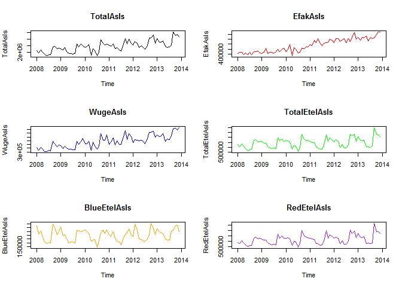

```r
par(mfrow=c(3,2))

plot(TotalAsIs, col="black", main="TotalAsIs")
plot(EfakAsIs , col="red",main="EfakAsIs")
plot(WugeAsIs, col="blue", main="WugeAsIs")
plot(TotalEtelAsIs, col="green",main="TotalEtelAsIs")
plot(BlueEtelAsIs, col="orange", main="BlueEtelAsIs")
plot(RedEtelAsIs, col="purple", main="RedEtelAsIs")
```

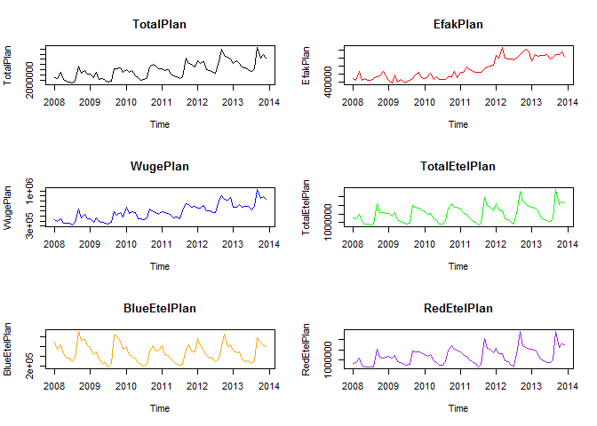

```r
plot(TotalPlan , col="black", main="TotalPlan")
plot(EfakPlan , col="red",main="EfakPlan")
plot(WugePlan, col="blue", main="WugePlan")
plot(TotalEtelPlan, col="green",main="TotalEtelPlan")
plot(BlueEtelPlan, col="orange", main="BlueEtelPlan")
plot(RedEtelPlan, col="purple", main="RedEtelPlan")
```

```r
cor(TotalAsIs, TotalPlan )
```

```
## [1] 0.9183402
```

```r
cor(EfakAsIs , EfakPlan)
```

```
## [1] 0.9055081
```

```r
cor(WugeAsIs, WugePlan)
```

```
## [1] 0.8788474
```

```r
cor(TotalEtelAsIs, TotalEtelPlan)
```

```
## [1] 0.9159505
```

```r
cor(BlueEtelAsIs , BlueEtelPlan)
```

```
## [1] 0.8044146
```

```r
cor(RedEtelAsIs , RedEtelPlan)
```

```
## [1] 0.9106702
```

```r
cor(YearAsIs, YearPlan)
```

```
## [1] 0.9627401
```

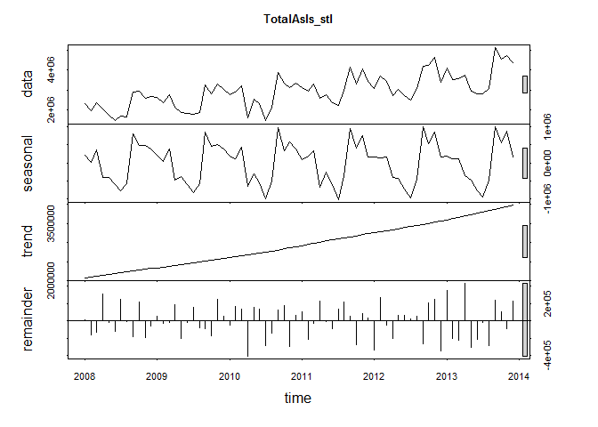

```r
par(mfrow=c(3,2))

plot(TotalAsIs_stl, col="black", main="TotalAsIs_stl")
```

```r
TotalAsIs_stl
```

```
##  Call:
##  stl(x = TotalAsIs, s.window = 5)
##
## Components
##             seasonal   trend  remainder
## Jan 2008   223320.67 2074233   15667.16
## Feb 2008    17036.99 2096208 -163113.80
## Mar 2008   361473.74 2118182 -133021.18
## Apr 2008  -410834.24 2140157  310464.16
## May 2008  -391831.93 2162114  -13317.80
## Jun 2008  -608564.13 2184070 -117204.25
## Jul 2008  -777993.52 2206027  251603.49
## Aug 2008  -583615.66 2228213   -4927.72
## Sep 2008   810939.36 2250400 -178453.09
## Oct 2008   474131.86 2272586  212998.05
## Nov 2008   488504.52 2294373 -186383.79
## Dec 2008   395452.58 2316160  -55045.03
## Jan 2009   217151.38 2337948   55473.99
## Feb 2009    39716.91 2359168  -27558.10
## Mar 2009   378507.21 2380389  -15109.96
## Apr 2009  -467522.18 2401609  191220.87
## May 2009  -371597.89 2425515 -203844.26
## Jun 2009  -595724.45 2449421  -17474.54
## Jul 2009  -827029.12 2473327  151013.28
## Aug 2009  -567342.69 2495885  -76573.99
## Sep 2009   843160.68 2518443  -90432.21
## Oct 2009   447562.71 2541000 -169675.09
## Nov 2009   497312.47 2562364  251099.75
## Dec 2009   388265.67 2583727   50520.14
## Jan 2010   201133.54 2605091  -45536.12
## Feb 2010   122776.46 2628120  167436.40
## Mar 2010   442825.47 2651150  133065.83
## Apr 2010  -652923.75 2674179 -407367.50
## May 2010  -301149.68 2698691  152615.46
## Jun 2010  -543850.29 2723203  138292.09
## Jul 2010  -985987.99 2747715 -287583.18
## Aug 2010  -487941.31 2774544 -138081.68
## Sep 2010   972415.73 2801373  124782.46
## Oct 2010   343206.82 2828202  177544.55
## Nov 2010   573281.74 2858572 -295909.05
```

[output cut: 22 more lines]

```
## Oct 2012   523934.85 3497123  207665.66
## Nov 2012   847979.72 3527674  242886.44
## Dec 2012   172550.29 3558224 -347101.49
## Jan 2013   184195.89 3588775  346555.55
## Feb 2013   114297.14 3623803 -202355.91
## Mar 2013   121000.80 3658831 -218857.78
## Apr 2013  -360531.42 3693859  426737.22
## May 2013  -462506.26 3728897 -306457.92
## Jun 2013  -759940.89 3763935 -216096.28
## Jul 2013  -951772.71 3798973  -18456.45
## Aug 2013  -468011.67 3834192 -282067.53
## Sep 2013  1004335.28 3869411  234028.47
## Oct 2013   554713.70 3904630  102800.01
## Nov 2013   873598.66 3940742  -85027.53
## Dec 2013   169104.03 3976853  226223.51
```

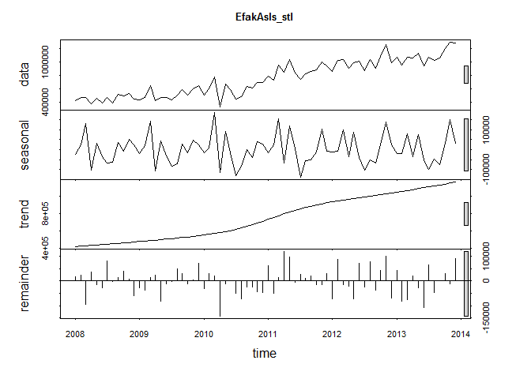

```r
plot(EfakAsIs_stl, col="black", main="EfakAsIs_stl")
```

```r
EfakAsIs_stl
```

```
##  Call:
##  stl(x = EfakAsIs, s.window = 5)
##
## Components
##               seasonal     trend     remainder
## Jan 2008  -23226.82900  423043.7   16772.17796
## Feb 2008   21521.59151  427584.6   23458.85001
## Mar 2008  130397.87276  432125.5  -95984.33867
## Apr 2008 -103571.06289  436666.4   37678.68955
## May 2008   32361.63887  441237.6  -15858.25182
## Jun 2008  -34947.71796  445808.9  -26044.13459
## Jul 2008  -68369.51749  450380.1   82491.42533
## Aug 2008  -63706.88476  455205.5   -2485.57353
## Sep 2008   34770.96136  460030.8   13568.21423
## Oct 2008   -8531.14784  464856.2   39272.95731
## Nov 2008   50984.15465  470083.3    8123.53058
## Dec 2008   24434.06358  475310.4  -58199.50258
## Jan 2009  -21569.57080  480537.6  -28912.99242
## Feb 2009   19658.97342  486282.6  -37754.60334
## Mar 2009  141908.71866  492027.7   14645.58472
## Apr 2009 -107360.30397  497772.8   24577.54065
## May 2009   44562.88090  503523.1  -81756.97423
## Jun 2009  -31331.51204  509273.4  -12166.91132
## Jul 2009  -81781.12397  515023.8   -2254.62940
## Aug 2009  -69071.52656  521175.9   50394.64064
## Sep 2009   26350.13821  527328.0   31304.84331
## Oct 2009  -15814.61747  533480.2  -10788.53357
## Nov 2009   47428.78524  540381.2    5895.06467
## Dec 2009   22883.82560  547282.1   71416.02525
## Jan 2010  -16429.66699  554183.1  -29576.48120
## Feb 2010    8122.84784  562923.9   30068.22351
## Mar 2010  185562.10056  571664.7   18769.19033
## Apr 2010 -113961.74775  580405.5 -142911.74181
## May 2010   89827.30170  593062.5  -10878.84059
## Jun 2010  -16097.25263  605719.6     272.66442
## Jul 2010 -128865.59745  618376.6  -51171.04008
## Aug 2010  -80958.67066  636091.3  -71769.64887
## Sep 2010     -14.97259  653806.0  -23727.02894
## Oct 2010  -39524.32045  671520.7  -23054.36308
## Nov 2010   40055.68302  692153.3  -44153.98494
```

[output cut: 22 more lines]

```
## Oct 2012   23112.61134 1012904.2   43977.21571
## Nov 2012  137745.56186 1022025.2   99959.18819
## Dec 2012   23773.31272 1031146.3  -67957.63968
## Jan 2013  -18512.22742 1040267.4   43341.82347
## Feb 2013  -18282.89519 1050818.1  -80340.21432
## Mar 2013   76998.74701 1061368.8  -75475.56207
## Apr 2013  -34796.61851 1071919.5   20865.09790
## May 2013   73853.95937 1082424.8  -28346.76511
## Jun 2013  -52105.72817 1092930.1 -107459.36269
## Jul 2013  -97209.87867 1103435.4   63641.50269
## Aug 2013  -48663.68800 1114155.6  -45413.95876
## Sep 2013  -74852.23174 1124875.9     -53.68579
## Oct 2013   31635.10429 1135596.2   30220.70741
## Nov 2013  147615.38092 1146745.6  -10391.00983
## Dec 2013   31201.96743 1157895.1   91737.96304
```

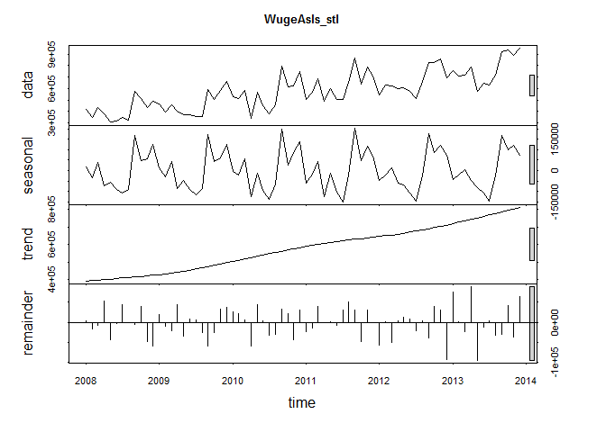

```r
plot(WugeAsIs_stl, col="black", main="WugeAsIs_stl")
```

```r
WugeAsIs_stl
```

```
##  Call:
##  stl(x = WugeAsIs, s.window = 5)
##
## Components
##             seasonal    trend   remainder
## Jan 2008   17722.170 392636.3   4212.5578
## Feb 2008  -33320.951 395527.0 -17627.0006
## Mar 2008   38455.870 398417.6  -6966.5016
## Apr 2008  -73928.951 401308.3  52226.6404
## May 2008  -55514.316 404310.6 -43099.2740
## Jun 2008  -89778.998 407312.9  -2951.8720
## Jul 2008 -108133.931 410315.1  44618.7814
## Aug 2008  -89728.129 413488.8   -142.7021
## Sep 2008  166874.291 416662.5  -5284.8039
## Oct 2008   49901.029 419836.2  40293.7760
## Nov 2008   57220.402 423065.3 -48805.7256
## Dec 2008  123616.460 426294.5 -59975.9117
## Jan 2009   12688.287 429523.6  20556.1337
## Feb 2009  -30520.192 433831.0  -9370.8179
## Mar 2009   41876.028 438138.4 -21528.4679
## Apr 2009  -85988.220 442445.9  45077.3498
## May 2009  -46542.229 448786.3 -34397.0515
## Jun 2009  -91250.863 455126.7   9334.1726
## Jul 2009 -115191.118 461467.1   5250.0168
## Aug 2009  -85325.179 468631.5 -24630.3220
## Sep 2009  173206.980 475795.9 -59403.8801
## Oct 2009   44475.519 482960.3 -26286.8189
## Nov 2009   62039.072 490099.1  33901.8208
## Dec 2009  125555.281 497237.9  36963.8053
## Jan 2010   -5520.274 504376.7  26450.5535
## Feb 2010  -19335.616 511854.9  22682.7384
## Mar 2010   55758.299 519333.0   6580.6663
## Apr 2010 -126076.519 526811.2 -60083.6720
## May 2010  -13363.506 534244.1  44986.4116
## Jun 2010  -94563.622 541677.0   3143.6233
## Jul 2010 -138490.382 549109.9 -31666.5198
## Aug 2010  -65027.981 555882.4 -31108.4072
## Sep 2010  196673.438 562654.9  32689.6863
## Oct 2010   24573.171 569427.4  22163.4670
## Nov 2010   88287.251 576395.1 -43709.3021
```

[output cut: 22 more lines]

```
## Oct 2012   87303.711 696882.9  40319.3912
## Nov 2012  121212.891 704258.8  30260.3453
## Dec 2012   73368.067 711634.6 -93894.6959
## Jan 2013  -41492.906 719010.5  75167.4116
## Feb 2013  -21062.252 727322.9   1981.3738
## Mar 2013    5722.875 735635.3 -22190.1365
## Apr 2013  -44997.170 743947.6  88417.5246
## May 2013  -81751.981 752332.7 -95859.7318
## Jun 2013 -105955.722 760717.8 -11133.0578
## Jul 2013 -144927.224 769102.8   3959.3771
## Aug 2013  -26223.829 777442.9 -32677.0385
## Sep 2013  168189.880 785782.9 -30389.7689
## Oct 2013   97959.387 794122.9  42151.7035
## Nov 2013  121683.011 802536.0 -37447.0602
## Dec 2013   72799.891 810949.2  65185.9191
```

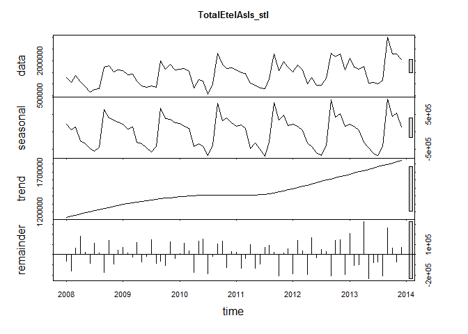

```r
plot(TotalEtelAsIs_stl, col="black", main="TotalEtelAsIs_stl")
```

```r
TotalEtelAsIs_stl
```

```
##  Call:
##  stl(x = TotalEtelAsIs, s.window = 5)
##
## Components
##            seasonal   trend   remainder
## Jan 2008  212543.90 1135393  -68268.686
## Feb 2008   64724.69 1149373 -160772.697
## Mar 2008  141647.42 1163353   62519.359
## Apr 2008 -264999.95 1177333  178391.504
## May 2008 -339776.29 1191010   22334.080
## Jun 2008 -473456.92 1204687  -86751.057
## Jul 2008 -560479.22 1218364  114773.472
## Aug 2008 -439963.23 1231709   14995.207
## Sep 2008  649360.43 1245054 -179149.730
## Oct 2008  394715.11 1258400  142636.314
## Nov 2008  343804.99 1270718  -96234.645
## Dec 2008  272635.02 1283036   45653.230
## Jan 2009  216526.66 1295354   71335.502
## Feb 2009   85366.77 1304840   17181.430
## Mar 2009  134597.06 1314326  -28121.833
## Apr 2009 -299576.10 1323812  116864.362
## May 2009 -339425.04 1333273  -73988.443
## Jun 2009 -463451.32 1342735  -20407.903
## Jul 2009 -588086.05 1352197  146023.090
## Aug 2009 -428334.97 1359570  -88185.300
## Sep 2009  684000.28 1366944  -69380.862
## Oct 2009  378107.74 1374317 -104490.629
## Nov 2009  350361.28 1380061  127414.131
## Dec 2009  269269.49 1385804  -39982.767
## Jan 2010  237811.58 1391548    8104.442
## Feb 2010  164697.76 1396069  115393.780
## Mar 2010  108887.92 1400591   40081.142
## Apr 2010 -414588.58 1405112 -177054.835
## May 2010 -341339.97 1406966  132774.500
## Jun 2010 -426196.92 1408821  157400.399
## Jul 2010 -672372.03 1410675 -187034.545
## Aug 2010 -377863.24 1410092  -19686.420
## Sep 2010  818966.77 1409509  107012.482
## Oct 2010  310866.57 1408926  136471.594
## Nov 2010  396380.37 1408474 -126731.546
```

[output cut: 22 more lines]

```
## Oct 2012  411978.67 1626922  138994.561
## Nov 2012  520321.23 1641216  144786.748
## Dec 2012  157545.15 1655510 -194908.427
## Jan 2013  228279.54 1669805  211412.939
## Feb 2013  159093.45 1685663 -106559.227
## Mar 2013   32529.79 1701521 -100106.827
## Apr 2013 -295207.15 1717379  322919.852
## May 2013 -454478.79 1733056 -239128.325
## Jun 2013 -615888.66 1748733  -78643.269
## Jul 2013 -688356.21 1764410  -72887.536
## Aug 2013 -417329.54 1779986 -207981.755
## Sep 2013  944212.59 1795563  261153.561
## Oct 2013  431257.90 1811139   63207.703
## Nov 2013  530407.87 1827035  -72771.039
## Dec 2013  148706.84 1842931   70522.228
```

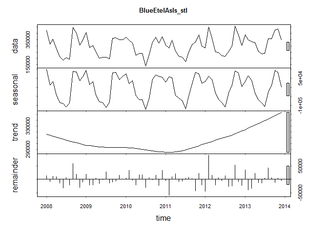

```r
plot(BlueEtelAsIs_stl, col="black", main="BlueEtelAsIs_stl")
```

```r
BlueEtelAsIs_stl
```

```
##  Call:
##  stl(x = BlueEtelAsIs, s.window = 5)
##
## Components
##              seasonal    trend    remainder
## Jan 2008   97275.2686 315974.4  12642.32237
## Feb 2008   11139.0385 314282.3  -8790.29761
## Mar 2008   30181.1498 312590.1  10740.74095
## Apr 2008  -41604.1720 310898.0   9417.21264
## May 2008  -82250.9857 309242.2 -14051.23490
## Jun 2008  -87353.5760 307586.5 -32383.90582
## Jul 2008 -105927.8088 305930.7   6282.06573
## Aug 2008  -86477.3535 304328.8 -22041.43484
## Sep 2008   86898.6482 302726.8  59107.51812
## Oct 2008   83770.5178 301124.9  18431.60318
## Nov 2008   36900.0663 299701.7 -30430.81279
## Dec 2008   58228.6185 298278.6 -10552.23250
## Jan 2009   92163.8208 296855.5  18404.69768
## Feb 2009   13669.0992 296096.5 -22111.62110
## Mar 2009   31435.5679 295337.6 -21615.13008
## Apr 2009  -42500.6886 294578.6   3609.08610
## May 2009  -78661.8281 294146.4 -15416.55261
## Jun 2009  -82645.8853 293714.2   -950.27369
## Jul 2009 -108839.2262 293281.9  27225.28892
## Aug 2009  -81026.1051 293227.4 -13729.28107
## Sep 2009   78685.0819 293172.8 -10154.91706
## Oct 2009   81277.8262 293118.3  -7986.11032
## Nov 2009   41681.4715 293074.7  15439.81387
## Dec 2009   58704.1866 293031.1    -84.33172
## Jan 2010   72580.1351 292987.6   4215.28931
## Feb 2010   20498.2214 292532.9  32112.89956
## Mar 2010   34939.9947 292078.2  -4323.17717
## Apr 2010  -45620.9710 291623.5 -22161.51489
## May 2010  -67265.4495 290733.7  15972.70036
## Jun 2010  -66554.3702 289844.0  17026.35768
## Jul 2010 -119001.0705 288954.3 -31349.20536
## Aug 2010  -62538.0386 288086.0   5631.04452
## Sep 2010   44273.8739 287217.7  -2401.58625
## Oct 2010   67997.9357 286349.4  14236.63364
## Nov 2010   59212.5980 285847.9 -24113.45064
```

[output cut: 22 more lines]

```
## Oct 2012   89271.6698 316328.6  51994.75448
## Nov 2012   78575.5205 318810.9  -8469.37352
## Dec 2012    4838.5499 321293.1 -22681.68023
## Jan 2013   29411.7297 323775.4  34309.86273
## Feb 2013   62361.5103 326372.9 -39721.41087
## Mar 2013   38868.3697 328970.4 -33564.76325
## Apr 2013  -29333.0223 331567.9  22817.13583
## May 2013  -66822.9596 334198.4 -11959.48200
## Jun 2013  -86068.6022 336829.0 -13741.39449
## Jul 2013 -103603.1850 339459.6   3190.63314
## Aug 2013  -26521.6173 342232.5  42841.07133
## Sep 2013    9112.7410 345005.5   5584.71890
## Oct 2013   92262.6860 347778.5 -12360.22031
## Nov 2013   79848.3267 350650.9   4061.78244
## Dec 2013     279.0305 353523.2  -5244.27796
```

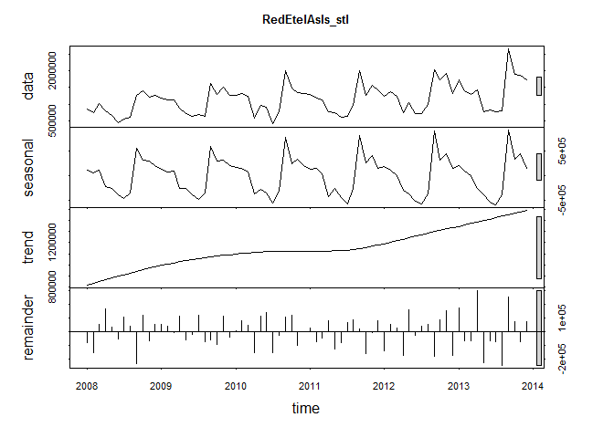

```r
plot(RedEtelAsIs_stl, col="black", main="RedEtelAsIs_stl")
```

```r
RedEtelAsIs_stl
```

```
##  Call:
##  stl(x = RedEtelAsIs, s.window = 5)
##
## Components
##             seasonal     trend   remainder
## Jan 2008  115268.835  819418.3  -80911.162
## Feb 2008   53585.615  835090.7 -151982.316
## Mar 2008  111466.463  850763.1   51778.461
## Apr 2008 -223395.889  866435.4  168974.440
## May 2008 -257525.355  881768.0   36385.394
## Jun 2008 -386103.162  897100.5  -54367.310
## Jul 2008 -454551.470  912433.0  108491.485
## Aug 2008 -353485.938  927380.2   37036.720
## Sep 2008  562461.720  942327.5 -238257.172
## Oct 2008  310944.528  957274.7  124204.786
## Nov 2008  306904.849  971015.9  -65803.760
## Dec 2008  214406.334  984757.1   56205.531
## Jan 2009  124363.076  998498.4   52930.565
## Feb 2009   71697.616 1008743.3   39293.091
## Mar 2009  103161.725 1018988.2   -6506.953
## Apr 2009 -257075.580 1029233.2  113255.418
## May 2009 -260763.268 1039127.1  -58571.874
## Jun 2009 -380805.212 1049021.1  -19457.912
## Jul 2009 -479246.894 1058915.1  118797.789
## Aug 2009 -347308.936 1066343.0  -74456.050
## Sep 2009  605315.129 1073770.9  -59225.996
## Oct 2009  296829.840 1081198.7  -96504.588
## Nov 2009  308679.739 1086986.0  111974.233
## Dec 2009  210565.226 1092773.3  -39898.534
## Jan 2010  165231.780 1098560.6    3889.633
## Feb 2010  144199.451 1103536.8   83280.783
## Mar 2010   73948.266 1108512.9   44404.788
## Apr 2010 -368967.981 1113489.1 -154893.145
## May 2010 -274074.598 1116232.9  116801.697
## Jun 2010 -359642.195 1118976.7  140374.518
## Jul 2010 -553371.024 1121720.5 -155685.429
## Aug 2010 -315325.262 1122005.8  -25317.534
## Sep 2010  774692.841 1122291.1  109414.018
## Oct 2010  242868.585 1122576.5  122234.930
## Nov 2010  337167.718 1122626.4 -102618.100
```

[output cut: 22 more lines]

```
## Oct 2012  322707.245 1310593.3   87000.416
## Nov 2012  441745.957 1322405.3  153256.733
## Dec 2012  152706.817 1334217.3 -172227.099
## Jan 2013  198867.808 1346029.3  177102.939
## Feb 2013   96731.864 1359290.0  -66837.878
## Mar 2013   -6338.588 1372550.8  -66542.188
## Apr 2013 -265875.136 1385811.5  300102.598
## May 2013 -387655.909 1398857.8 -227168.886
## Jun 2013 -529820.071 1411904.1  -64901.981
## Jul 2013 -584752.754 1424950.3  -76077.555
## Aug 2013 -390807.670 1437753.9 -250823.189
## Sep 2013  935099.766 1450557.4  255568.824
## Oct 2013  338995.467 1463361.0   75567.574
## Nov 2013  450559.803 1476384.4  -76833.165
## Dec 2013  148428.084 1489407.8   75767.153
```

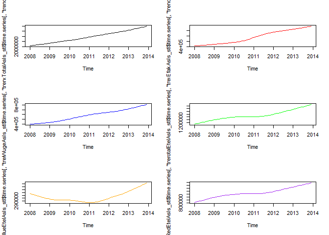

```r
par(mfrow=c(3,2))

plot(TotalAsIs_stl$time.series[,"trend"], col="black")
plot(EfakAsIs_stl$time.series[,"trend"], col="red")
plot(WugeAsIs_stl$time.series[,"trend"], col="blue")
plot(TotalEtelAsIs_stl$time.series[,"trend"], col="green")
plot(BlueEtelAsIs_stl$time.series[,"trend"], col="orange")
plot(RedEtelAsIs_stl$time.series[,"trend"], col="purple")
```

## Forecasts with the models

First shorten the time series in order to test the forecasts. Shortening the exports data and indicators in the Time Series in order to be able to compare the produced forecasts with the As Is data.

## Forecasting and testing the models

### Forecast ModelWithHighCorrelatingIndicators

Shorten ModelWithHighCorrelatingIndicators by one year in order to be able to produce a forecast for 2013.

```r
ModelWithHighCorrelatingIndicators_2012 <- tslm(TotalAsIs_2012 ~ trend + season + CEPI_2012 + SIExtern_2012 + UrbanoExports_2012 + GlobalisationPartyMembers_2012 + AEPI_2012)
summary(ModelWithHighCorrelatingIndicators_2012)
```

```
##
## Call:
## tslm(formula = TotalAsIs_2012 ~ trend + season + CEPI_2012 +
##     SIExtern_2012 + UrbanoExports_2012 + GlobalisationPartyMembers_2012 +
##     AEPI_2012)
##
## Residuals:
##     Min      1Q  Median      3Q     Max
## -590682 -148874   23944  148648  423243
##
## Coefficients:
##                                  Estimate Std. Error t value Pr(>|t|)
## (Intercept)                    -1.542e+07  1.461e+07  -1.056 0.297224
## trend                           2.827e+02  2.096e+04   0.013 0.989301
## season2                        -1.071e+05  1.777e+05  -0.603 0.549946
## season3                         6.219e+04  2.031e+05   0.306 0.760993
## season4                        -7.186e+05  1.935e+05  -3.715 0.000595 ***
## season5                        -5.757e+05  1.978e+05  -2.910 0.005752 **
## season6                        -8.241e+05  1.994e+05  -4.134 0.000167 ***
## season7                        -1.083e+06  2.186e+05  -4.955 1.23e-05 ***
## season8                        -6.963e+05  2.236e+05  -3.113 0.003325 **
## season9                         6.649e+05  2.219e+05   2.996 0.004572 **
## season10                        3.046e+05  2.223e+05   1.370 0.177909
## season11                        5.136e+05  2.230e+05   2.303 0.026314 *
## season12                        4.974e+04  2.530e+05   0.197 0.845057
## CEPI_2012                       2.248e+05  1.922e+05   1.169 0.248882
## SIExtern_2012                   2.369e+04  4.590e+04   0.516 0.608451
## UrbanoExports_2012             -1.522e-01  5.208e-01  -0.292 0.771535
## GlobalisationPartyMembers_2012  3.142e+01  3.844e+01   0.817 0.418370
## AEPI_2012                      -4.974e+04  6.236e+04  -0.798 0.429556
## ---
## Signif. codes:  0 '***' 0.001 '**' 0.01 '*' 0.05 '.' 0.1 ' ' 1
##
## Residual standard error: 256600 on 42 degrees of freedom
## Multiple R-squared:  0.9145, Adjusted R-squared:  0.8798
## F-statistic: 26.41 on 17 and 42 DF,  p-value: < 2.2e-16
```

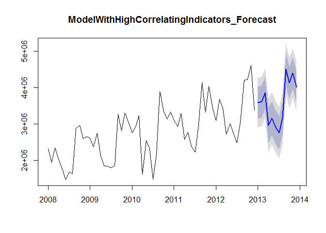

```r
# Add "newdata" to the 2013 indicator values for the forecast
ModelWithHighCorrelatingIndicators_Forecast <- forecast(ModelWithHighCorrelatingIndicators_2012,newdata=data.frame(CEPI_2012=CEPI_2013, SIExtern_2012=SIExtern_2013, UrbanoExports_2012= UrbanoExports_2013, GlobalisationPartyMembers_2012=GlobalisationPartyMembers_2013, AEPI_2012=AEPI_2013),h=12)
plot(ModelWithHighCorrelatingIndicators_Forecast, main="ModelWithHighCorrelatingIndicators_Forecast")
```

```r
ModelWithHighCorrelatingIndicators_Forecast
```

```
##          Point Forecast   Lo 80   Hi 80   Lo 95   Hi 95
## Jan 2013        3588409 3145307 4031511 2901625 4275193
## Feb 2013        3615751 3174780 4056722 2932271 4299231
## Mar 2013        3857685 3418316 4297055 3176687 4538684
## Apr 2013        2959830 2478742 3440918 2214171 3705489
## May 2013        3163014 2698603 3627424 2443204 3882824
## Jun 2013        2934791 2472811 3396771 2218748 3650835
## Jul 2013        2755659 2296827 3214490 2044495 3466822
## Aug 2013        3167751 2707972 3627531 2455119 3880384
## Sep 2013        4512206 4061044 4963367 3812930 5211481
## Oct 2013        4129962 3677062 4582861 3427993 4831931
## Nov 2013        4398869 3963060 4834678 3723389 5074349
## Dec 2013        4019999 3580235 4459762 3338390 4701608
```

```r
# In order to be able to correlate the Forecast with the As Is Data, it is necessary to convert the Point
# Estimator into a time series.
ModelWithHighCorrelatingIndicators_Forecast_df <-as.data.frame(ModelWithHighCorrelatingIndicators_Forecast)
ModelWithHighCorrelatingIndicators_PointForecast <- ts(ModelWithHighCorrelatingIndicators_Forecast_df$"Point Forecast", start=c(2013,1), end=c(2013,12), frequency=12)

# Correlation of the forecasts and As Is Data. As a comparison, the correlation of the As Is Data for 2013 with the Plan Data.
cor(ModelWithHighCorrelatingIndicators_PointForecast, TotalAsIs_2013)
```

```
## [1] 0.9028604
```

```r
cor(TotalAsIs_2013, TotalPlan_2013)
```

```
## [1] 0.929769
```

```r
# A Comparison with linear regression also supports the result.
ModelWithHighCorrelatingIndicators_forecast_lm <- lm(TotalAsIs_2013 ~ ModelWithHighCorrelatingIndicators_PointForecast, data = TotalAsIs_2013)
TotalAsIs_2013_lm <- lm(TotalAsIs_2013 ~ TotalPlan_2013, data = TotalAsIs_2013)
summary(ModelWithHighCorrelatingIndicators_forecast_lm)
```

```
##
## Call:
## lm(formula = TotalAsIs_2013 ~ ModelWithHighCorrelatingIndicators_PointForecast,
##     data = TotalAsIs_2013)
##
## Residuals:
##     Min      1Q  Median      3Q     Max
## -540546 -227283   12596  157487  731430
##
## Coefficients:
##                                                    Estimate Std. Error
## (Intercept)                                      -5.082e+05  6.545e+05
## ModelWithHighCorrelatingIndicators_PointForecast  1.195e+00  1.799e-01
##                                                  t value Pr(>|t|)
## (Intercept)                                       -0.776    0.455
## ModelWithHighCorrelatingIndicators_PointForecast   6.641 5.78e-05 ***
## ---
## Signif. codes:  0 '***' 0.001 '**' 0.01 '*' 0.05 '.' 0.1 ' ' 1
##
## Residual standard error: 357000 on 10 degrees of freedom
## Multiple R-squared:  0.8152, Adjusted R-squared:  0.7967
## F-statistic:  44.1 on 1 and 10 DF,  p-value: 5.776e-05
```

```r
summary(TotalAsIs_2013_lm)
```

```
##
## Call:
## lm(formula = TotalAsIs_2013 ~ TotalPlan_2013, data = TotalAsIs_2013)
##
## Residuals:
##     Min      1Q  Median      3Q     Max
## -441885 -227385  -43470  184761  466401
##
## Coefficients:
##                  Estimate Std. Error t value Pr(>|t|)
## (Intercept)    -8.972e+04  4.930e+05  -0.182    0.859
## TotalPlan_2013  1.053e+00  1.318e-01   7.987  1.2e-05 ***
## ---
## Signif. codes:  0 '***' 0.001 '**' 0.01 '*' 0.05 '.' 0.1 ' ' 1
##
## Residual standard error: 305700 on 10 degrees of freedom
## Multiple R-squared:  0.8645, Adjusted R-squared:  0.8509
## F-statistic: 63.78 on 1 and 10 DF,  p-value: 1.195e-05
```

### Forecast ModelWithLowCorrelatingIndicators

Shorten ModelWithLowCorrelatingIndicators by one year in order to be able to produce a forecast for 2013.

```r
ModelWithLowCorrelatingIndicators_2012 <- tslm(TotalAsIs_2012 ~ trend + season + NationalHolidays_2012 + UrbanoExports_2012 + GlobalisationPartyMembers_2012)
summary(ModelWithLowCorrelatingIndicators_2012)
```

```
##
## Call:
## tslm(formula = TotalAsIs_2012 ~ trend + season + NationalHolidays_2012 +
##     UrbanoExports_2012 + GlobalisationPartyMembers_2012)
##
## Residuals:
##     Min      1Q  Median      3Q     Max
## -508808 -130098   11746  177748  466017
##
## Coefficients:
##                                  Estimate Std. Error t value Pr(>|t|)
## (Intercept)                     1.211e+06  1.549e+06   0.782 0.438428
## trend                           2.004e+04  1.028e+04   1.950 0.057515 .
## season2                        -2.898e+04  1.573e+05  -0.184 0.854714
## season3                         2.520e+05  1.631e+05   1.545 0.129609
## season4                        -3.800e+05  2.242e+05  -1.695 0.097100 .
## season5                        -4.697e+05  1.623e+05  -2.894 0.005897 **
## season6                        -7.350e+05  1.652e+05  -4.450 5.79e-05 ***
## season7                        -9.668e+05  1.687e+05  -5.732 8.35e-07 ***
## season8                        -5.809e+05  1.727e+05  -3.364 0.001602 **
## season9                         7.426e+05  1.772e+05   4.190 0.000132 ***
## season10                        3.765e+05  1.822e+05   2.066 0.044712 *
## season11                        5.612e+05  1.876e+05   2.991 0.004541 **
## season12                        4.716e+05  2.756e+05   1.711 0.094062 .
## NationalHolidays_2012          -3.051e+05  1.962e+05  -1.554 0.127234
## UrbanoExports_2012              1.218e-01  1.838e-01   0.663 0.510937
## GlobalisationPartyMembers_2012  5.692e+00  2.753e+01   0.207 0.837165
## ---
## Signif. codes:  0 '***' 0.001 '**' 0.01 '*' 0.05 '.' 0.1 ' ' 1
##
## Residual standard error: 248200 on 44 degrees of freedom
## Multiple R-squared:  0.9162, Adjusted R-squared:  0.8876
## F-statistic: 32.05 on 15 and 44 DF,  p-value: < 2.2e-16
```

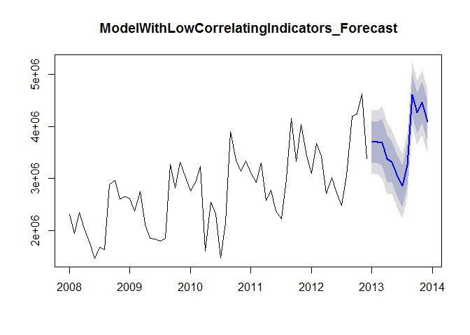

```r
# Add "newdata" to the 2013 indicator values for the forecast
ModelWithLowCorrelatingIndicators_Forecast <- forecast(ModelWithLowCorrelatingIndicators_2012,newdata=data.frame(NationalHolidays_2012=NationalHolidays_2013, UrbanoExports_2012= UrbanoExports_2013, GlobalisationPartyMembers_2012=GlobalisationPartyMembers_2013),h=12)
plot(ModelWithLowCorrelatingIndicators_Forecast, main="ModelWithLowCorrelatingIndicators_Forecast")
```

```r
ModelWithLowCorrelatingIndicators_Forecast
```

```
##          Point Forecast   Lo 80   Hi 80   Lo 95   Hi 95
## Jan 2013        3703214 3306827 4099602 3089217 4317212
## Feb 2013        3694280 3297893 4090668 3080283 4308278
## Mar 2013        3690209 3244288 4136130 2999485 4380933
## Apr 2013        3383361 2937440 3829282 2692637 4074085
## May 2013        3313734 2917347 3710121 2699736 3927731
## Jun 2013        3068413 2672026 3464800 2454415 3682410
## Jul 2013        2856693 2460306 3253081 2242696 3470691
## Aug 2013        3262648 2866261 3659036 2648651 3876646
## Sep 2013        4606119 4209732 5002506 3992121 5220117
## Oct 2013        4260121 3863734 4656508 3646123 4874119
## Nov 2013        4464894 4068507 4861282 3850897 5078892
## Dec 2013        4090225 3693837 4486612 3476227 4704222
```

```r
# In order to be able to correlate the Forecast with the As Is Data, it is necessary to convert the Point
# Estimator into a time series.
ModelWithLowCorrelatingIndicators_Forecast_df <-as.data.frame(ModelWithLowCorrelatingIndicators_Forecast)
ModelWithLowCorrelatingIndicators_PointForecast <- ts(ModelWithLowCorrelatingIndicators_Forecast_df$"Point Forecast", start=c(2013,1), end=c(2013,12), frequency=12)

# Correlation of the forecasts and As Is Data. As a comparison, the correlation of the As Is Data for 2013 with the Plan Data.
cor(ModelWithLowCorrelatingIndicators_PointForecast, TotalAsIs_2013)
```

```
## [1] 0.9590162
```

```r
cor(TotalAsIs_2013, TotalPlan_2013)
```

```
## [1] 0.929769
```

```r
# A Comparison with linear regression also supports the result.
ModelWithLowCorrelatingIndicators_forecast_lm <- lm(TotalAsIs_2013 ~ ModelWithLowCorrelatingIndicators_PointForecast, data = TotalAsIs_2013)
TotalAsIs_2013_lm <- lm(TotalAsIs_2013 ~ TotalPlan_2013, data = TotalAsIs_2013)
summary(ModelWithLowCorrelatingIndicators_forecast_lm)
```

```
##
## Call:
## lm(formula = TotalAsIs_2013 ~ ModelWithLowCorrelatingIndicators_PointForecast,
##     data = TotalAsIs_2013)
##
## Residuals:
##     Min      1Q  Median      3Q     Max
## -299026 -155463  -40768  115237  406333
##
## Coefficients:
##                                                   Estimate Std. Error
## (Intercept)                                     -1.252e+06  4.754e+05
## ModelWithLowCorrelatingIndicators_PointForecast  1.361e+00  1.272e-01
##                                                 t value Pr(>|t|)
## (Intercept)                                      -2.633    0.025 *
## ModelWithLowCorrelatingIndicators_PointForecast  10.703  8.5e-07 ***
## ---
## Signif. codes:  0 '***' 0.001 '**' 0.01 '*' 0.05 '.' 0.1 ' ' 1
##
## Residual standard error: 235300 on 10 degrees of freedom
## Multiple R-squared:  0.9197, Adjusted R-squared:  0.9117
## F-statistic: 114.6 on 1 and 10 DF,  p-value: 8.5e-07
```

```r
summary(TotalAsIs_2013_lm)
```

```
##
## Call:
## lm(formula = TotalAsIs_2013 ~ TotalPlan_2013, data = TotalAsIs_2013)
##
## Residuals:
##     Min      1Q  Median      3Q     Max
## -441885 -227385  -43470  184761  466401
##
## Coefficients:
##                  Estimate Std. Error t value Pr(>|t|)
## (Intercept)    -8.972e+04  4.930e+05  -0.182    0.859
## TotalPlan_2013  1.053e+00  1.318e-01   7.987  1.2e-05 ***
## ---
## Signif. codes:  0 '***' 0.001 '**' 0.01 '*' 0.05 '.' 0.1 ' ' 1
##
## Residual standard error: 305700 on 10 degrees of freedom
## Multiple R-squared:  0.8645, Adjusted R-squared:  0.8509
## F-statistic: 63.78 on 1 and 10 DF,  p-value: 1.195e-05
```

### Forecast ModelWithTrendAndSeasonalityOnly

Shorten ModelWithTrendAndSeasonalityOnly by one year in order to be able to produce a forecast for 2013.

```r
ModelWithTrendAndSeasonalityOnly_2012 <- tslm(TotalAsIs_2012 ~ trend + season)
summary(ModelWithTrendAndSeasonalityOnly_2012)
```

```
##
## Call:
## tslm(formula = TotalAsIs_2012 ~ trend + season)
##
## Residuals:
##     Min      1Q  Median      3Q     Max
## -600304 -116717   -7864  163111  473692
##
## Coefficients:
##             Estimate Std. Error t value Pr(>|t|)
## (Intercept)  2147793     120530  17.820  < 2e-16 ***
## trend          25212       1887  13.363  < 2e-16 ***
## season2       -34146     156872  -0.218 0.828632
## season3       180612     156906   1.151 0.255518
## season4      -639529     156962  -4.074 0.000176 ***
## season5      -490327     157042  -3.122 0.003068 **
## season6      -760860     157144  -4.842 1.43e-05 ***
## season7      -997792     157268  -6.345 8.09e-08 ***
## season8      -617048     157415  -3.920 0.000286 ***
## season9       701211     157585   4.450 5.26e-05 ***
## season10      330001     157777   2.092 0.041907 *
## season11      509563     157991   3.225 0.002292 **
## season12      109681     158227   0.693 0.491603
## ---
## Signif. codes:  0 '***' 0.001 '**' 0.01 '*' 0.05 '.' 0.1 ' ' 1
##
## Residual standard error: 248000 on 47 degrees of freedom
## Multiple R-squared:  0.9106, Adjusted R-squared:  0.8878
## F-statistic: 39.89 on 12 and 47 DF,  p-value: < 2.2e-16
```

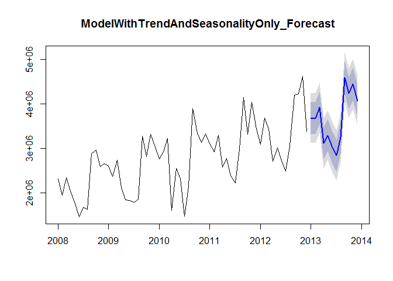

```r
# Add "newdata" to the 2013 indicator values for the forecast.
ModelWithTrendAndSeasonalityOnly_Forecast <- forecast(ModelWithTrendAndSeasonalityOnly_2012,h=12)
plot(ModelWithTrendAndSeasonalityOnly_Forecast, main="ModelWithTrendAndSeasonalityOnly_Forecast")
```

```r
ModelWithTrendAndSeasonalityOnly_Forecast
```

```
##          Point Forecast   Lo 80   Hi 80   Lo 95   Hi 95
## Jan 2013        3685709 3321691 4049727 3122318 4249100
## Feb 2013        3676775 3312757 4040793 3113384 4240166
## Mar 2013        3916745 3552727 4280763 3353354 4480136
## Apr 2013        3121815 2757797 3485833 2558424 3685206
## May 2013        3296229 2932211 3660247 2732838 3859620
## Jun 2013        3050908 2686890 3414926 2487517 3614299
## Jul 2013        2839188 2475170 3203206 2275797 3402579
## Aug 2013        3245143 2881125 3609161 2681752 3808534
## Sep 2013        4588614 4224596 4952632 4025223 5152005
## Oct 2013        4242616 3878598 4606634 3679225 4806007
## Nov 2013        4447389 4083371 4811407 3883998 5010780
## Dec 2013        4072720 3708702 4436737 3509329 4636110
```

```r
# In order to be able to correlate the Forecast with the As Is Data, it is necessary to convert the Point
# Estimator into a time series.
ModelWithTrendAndSeasonalityOnly_Forecast_df <-as.data.frame(ModelWithTrendAndSeasonalityOnly_Forecast)
ModelWithTrendAndSeasonalityOnly_PointForecast <- ts(ModelWithTrendAndSeasonalityOnly_Forecast_df$"Point Forecast", start=c(2013,1), end=c(2013,12), frequency=12)

# Correlation of the forecasts and As Is Data. As a comparison, the correlation of the As Is Data for 2013 with the Plan Data.
cor(ModelWithTrendAndSeasonalityOnly_PointForecast, TotalAsIs_2013)
```

```
## [1] 0.9138049
```

```r
cor(TotalAsIs_2013, TotalPlan_2013)
```

```
## [1] 0.929769
```

```r
# A Comparison with linear regression also supports the result.
ModelWithTrendAndSeasonalityOnly_Forecast_lm <- lm(TotalAsIs_2013 ~ ModelWithTrendAndSeasonalityOnly_PointForecast, data = TotalAsIs_2013)
TotalAsIs_2013_lm <- lm(TotalAsIs_2013 ~ TotalPlan_2013, data = TotalAsIs_2013)
summary(ModelWithTrendAndSeasonalityOnly_Forecast_lm)
```

```
##
## Call:
## lm(formula = TotalAsIs_2013 ~ ModelWithTrendAndSeasonalityOnly_PointForecast,
##     data = TotalAsIs_2013)
##
## Residuals:
##     Min      1Q  Median      3Q     Max
## -516239 -216450   33683  123007  675607
##
## Coefficients:
##                                                  Estimate Std. Error
## (Intercept)                                    -8.142e+05  6.536e+05
## ModelWithTrendAndSeasonalityOnly_PointForecast  1.249e+00  1.755e-01
##                                                t value Pr(>|t|)
## (Intercept)                                     -1.246    0.241
## ModelWithTrendAndSeasonalityOnly_PointForecast   7.115 3.24e-05 ***
## ---
## Signif. codes:  0 '***' 0.001 '**' 0.01 '*' 0.05 '.' 0.1 ' ' 1
##
## Residual standard error: 337300 on 10 degrees of freedom
## Multiple R-squared:  0.835,  Adjusted R-squared:  0.8185
## F-statistic: 50.62 on 1 and 10 DF,  p-value: 3.238e-05
```

```r
summary(TotalAsIs_2013_lm)
```

```
##
## Call:
## lm(formula = TotalAsIs_2013 ~ TotalPlan_2013, data = TotalAsIs_2013)
##
## Residuals:
##     Min      1Q  Median      3Q     Max
## -441885 -227385  -43470  184761  466401
##
## Coefficients:
##                  Estimate Std. Error t value Pr(>|t|)
## (Intercept)    -8.972e+04  4.930e+05  -0.182    0.859
## TotalPlan_2013  1.053e+00  1.318e-01   7.987  1.2e-05 ***
## ---
## Signif. codes:  0 '***' 0.001 '**' 0.01 '*' 0.05 '.' 0.1 ' ' 1
##
## Residual standard error: 305700 on 10 degrees of freedom
## Multiple R-squared:  0.8645, Adjusted R-squared:  0.8509
## F-statistic: 63.78 on 1 and 10 DF,  p-value: 1.195e-05
```

### Forecast ModelWithEfakExportsIndicators

Shorten the variables in ModelWithEfakExportsIndicators by one year in order to be able to produce a forecast for 2013.

```r
ModelWithEfakExportsIndicators_2012 <- tslm(EfakAsIs_2012 ~ trend + season + CEPI_2012 + UrbanoExports_2012 + AEPI_2012)
ModelEfakSalesWithCEPI_2012 <- tslm(EfakAsIs_2012 ~ trend + season + CEPI_2012)
ModelEfakSalesWithTrendAnsSeasonalityOnly_2012 <- tslm(EfakAsIs_2012 ~ trend + season)
ModelWithCEPIOnly_2012 <- tslm(EfakAsIs_2012 ~ CEPI_2012)
summary(ModelWithEfakExportsIndicators_2012)
```

```
##
## Call:
## tslm(formula = EfakAsIs_2012 ~ trend + season + CEPI_2012 + UrbanoExports_2012 +
##     AEPI_2012)
##
## Residuals:
##     Min      1Q  Median      3Q     Max
## -176710  -50413    8239   35248  146391
##
## Coefficients:
##                      Estimate Std. Error t value Pr(>|t|)
## (Intercept)        -1.810e+06  2.908e+06  -0.622  0.53684
## trend               4.285e+03  2.516e+03   1.703  0.09562 .
## season2             5.273e+04  4.854e+04   1.086  0.28323
## season3             1.607e+05  5.440e+04   2.954  0.00503 **
## season4            -4.599e+04  5.317e+04  -0.865  0.39168
## season5             1.016e+05  5.404e+04   1.881  0.06666 .
## season6             2.951e+04  5.512e+04   0.535  0.59512
## season7            -4.571e+04  6.041e+04  -0.757  0.45334
## season8             6.598e+03  6.206e+04   0.106  0.91582
## season9             5.155e+04  6.111e+04   0.844  0.40345
## season10            6.691e+04  6.008e+04   1.114  0.27148
## season11            1.637e+05  5.900e+04   2.775  0.00808 **
## season12            8.394e+04  6.858e+04   1.224  0.22747
## CEPI_2012           2.407e+03  3.940e+04   0.061  0.95155
## UrbanoExports_2012  2.348e-01  1.413e-01   1.661  0.10374
## AEPI_2012           5.823e+03  1.420e+04   0.410  0.68375
## ---
## Signif. codes:  0 '***' 0.001 '**' 0.01 '*' 0.05 '.' 0.1 ' ' 1
##
## Residual standard error: 71560 on 44 degrees of freedom
## Multiple R-squared:  0.9294, Adjusted R-squared:  0.9053
## F-statistic: 38.59 on 15 and 44 DF,  p-value: < 2.2e-16
```

```r
summary(ModelEfakSalesWithCEPI_2012)
```

```
##
## Call:
## tslm(formula = EfakAsIs_2012 ~ trend + season + CEPI_2012)
##
## Residuals:
##     Min      1Q  Median      3Q     Max
## -205118  -45951    8303   48133  175186
##
## Coefficients:
##             Estimate Std. Error t value Pr(>|t|)
## (Intercept) -7424279    1546653  -4.800 1.71e-05 ***
## trend           2533       1977   1.282  0.20640
## season2        15685      47310   0.332  0.74174
## season3        96971      48168   2.013  0.04997 *
## season4      -104275      47657  -2.188  0.03378 *
## season5        37612      47571   0.791  0.43321
## season6       -37662      47501  -0.793  0.43192
## season7      -131181      48012  -2.732  0.00889 **
## season8       -84988      47994  -1.771  0.08322 .
## season9       -33902      47593  -0.712  0.47985
## season10      -16525      47364  -0.349  0.72876
## season11       84535      47226   1.790  0.08004 .
## season12      -27244      47895  -0.569  0.57225
## CEPI_2012      79863      15994   4.993 8.99e-06 ***
## ---
## Signif. codes:  0 '***' 0.001 '**' 0.01 '*' 0.05 '.' 0.1 ' ' 1
##
## Residual standard error: 74030 on 46 degrees of freedom
## Multiple R-squared:  0.921,  Adjusted R-squared:  0.8986
## F-statistic: 41.23 on 13 and 46 DF,  p-value: < 2.2e-16
```

```r
summary(ModelEfakSalesWithTrendAnsSeasonalityOnly_2012)
```

```
##
## Call:
## tslm(formula = EfakAsIs_2012 ~ trend + season)
##
## Residuals:
##     Min      1Q  Median      3Q     Max
## -248244  -48564    2962   44626  164771
##
## Coefficients:
##             Estimate Std. Error t value Pr(>|t|)
## (Intercept) 296701.0    44200.2   6.713 2.23e-08 ***
## trend        11994.9      691.9  17.336  < 2e-16 ***
## season2      49349.5    57527.4   0.858   0.3953
## season3     153118.7    57539.8   2.661   0.0106 *
## season4     -60783.2    57560.6  -1.056   0.2964
## season5      78031.6    57589.7   1.355   0.1819
## season6       -314.9    57627.1  -0.005   0.9957
## season7     -80934.3    57672.8  -1.403   0.1671
## season8     -36215.8    57726.7  -0.627   0.5335
## season9       2213.3    57788.9   0.038   0.9696
## season10      8532.1    57859.3   0.147   0.8834
## season11     96935.4    57937.8   1.673   0.1010
## season12     12432.6    58024.5   0.214   0.8313
## ---
## Signif. codes:  0 '***' 0.001 '**' 0.01 '*' 0.05 '.' 0.1 ' ' 1
##
## Residual standard error: 90950 on 47 degrees of freedom
## Multiple R-squared:  0.8781, Adjusted R-squared:  0.847
## F-statistic: 28.22 on 12 and 47 DF,  p-value: < 2.2e-16
```

```r
summary(ModelWithCEPIOnly_2012)
```

```
##
## Call:
## tslm(formula = EfakAsIs_2012 ~ CEPI_2012)
##
## Residuals:
##     Min      1Q  Median      3Q     Max
## -285729  -46717   -4540   53446  235068
##
## Coefficients:
##             Estimate Std. Error t value Pr(>|t|)
## (Intercept) -9183792     584004  -15.73   <2e-16 ***
## CEPI_2012      97931       5796   16.90   <2e-16 ***
## ---
## Signif. codes:  0 '***' 0.001 '**' 0.01 '*' 0.05 '.' 0.1 ' ' 1
##
## Residual standard error: 96370 on 58 degrees of freedom
## Multiple R-squared:  0.8311, Adjusted R-squared:  0.8282
## F-statistic: 285.5 on 1 and 58 DF,  p-value: < 2.2e-16
```

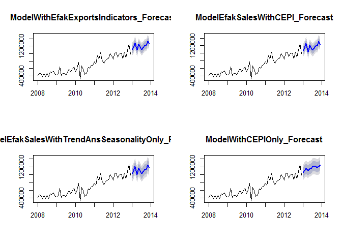

```r
# Add "newdata" to the 2013 indicator values for the forecast.
ModelWithEfakExportsIndicators_Forecast <- forecast(ModelWithEfakExportsIndicators_2012, newdata=data.frame(CEPI_2012=CEPI_2013, UrbanoExports_2012 = UrbanoExports_2013, AEPI_2012 = AEPI_2013),h=12)
ModelEfakSalesWithCEPI_Forecast <- forecast(ModelEfakSalesWithCEPI_2012,newdata=data.frame(CEPI_2012=CEPI_2013), h=12)
ModelEfakSalesWithTrendAnsSeasonalityOnly_Forecast <- forecast(ModelEfakSalesWithTrendAnsSeasonalityOnly_2012,h=12)
ModelWithCEPIOnly_Forecast <- forecast(ModelWithCEPIOnly_2012,newdata=data.frame(CEPI_2012=CEPI_2013), h=12)

par(mfrow=c(2,2))

plot(ModelWithEfakExportsIndicators_Forecast, main="ModelWithEfakExportsIndicators_Forecast")
plot(ModelEfakSalesWithCEPI_Forecast, main="ModelEfakSalesWithCEPI_Forecast")
plot(ModelEfakSalesWithTrendAnsSeasonalityOnly_Forecast, main="ModelEfakSalesWithTrendAnsSeasonalityOnly_Forecast")
plot(ModelWithCEPIOnly_Forecast, main="ModelWithCEPIOnly_Forecast")
```

```r
ModelWithEfakExportsIndicators_Forecast
```

```
##          Point Forecast   Lo 80   Hi 80     Lo 95   Hi 95
## Jan 2013        1114825 1005751 1223900  945870.9 1283780
## Feb 2013        1175033 1065668 1284399 1005627.7 1344439
## Mar 2013        1293717 1185544 1401889 1126159.0 1461275
## Apr 2013        1090702  979260 1202145  918079.9 1263325
## May 2013        1247057 1138259 1355856 1078530.0 1415584
## Jun 2013        1180055 1071566 1288545 1012006.6 1348104
## Jul 2013        1114988 1007070 1222906  947825.2 1282151
## Aug 2013        1168666 1060874 1276457 1001698.5 1335633
## Sep 2013        1219070 1111457 1326682 1052380.0 1385759
## Oct 2013        1234737 1126290 1343185 1066753.4 1402722
## Nov 2013        1335131 1227414 1442848 1168278.8 1501984
## Dec 2013        1261780 1153853 1369708 1094602.1 1428958
```

```r
ModelEfakSalesWithCEPI_Forecast
```

```
##          Point Forecast     Lo 80   Hi 80     Lo 95   Hi 95
## Jan 2013        1075911  966514.0 1185308  906552.6 1245269
## Feb 2013        1142047 1032502.0 1251592  972459.4 1311635
## Mar 2013        1265797 1155974.5 1375620 1095779.5 1435815
## Apr 2013        1027154  918285.8 1136021  858614.3 1195693
## May 2013        1203519 1094074.8 1312964 1034087.2 1372952
## Jun 2013        1138765 1029271.1 1248259  969256.4 1308274
## Jul 2013        1087711  977571.1 1197850  917202.6 1258218
## Aug 2013        1136438 1026614.7 1246261  966419.7 1306456
## Sep 2013        1190056 1080111.3 1300001 1019849.4 1360263
## Oct 2013        1193995 1084550.0 1303439 1024562.4 1363427
## Nov 2013        1313560 1203420.5 1423699 1143052.0 1484068
## Dec 2013        1236260 1126315.5 1346205 1066053.6 1406467
```

```r
ModelEfakSalesWithTrendAnsSeasonalityOnly_Forecast
```

```
##          Point Forecast     Lo 80   Hi 80     Lo 95   Hi 95
## Jan 2013        1028393  894901.3 1161884  821787.9 1234997
## Feb 2013        1089737  956245.7 1223228  883132.3 1296342
## Mar 2013        1205501 1072009.9 1338992  998896.5 1412106
## Apr 2013        1003594  870102.9 1137085  796989.5 1210199
## May 2013        1154404 1020912.7 1287895  947799.3 1361009
## Jun 2013        1088052  954561.1 1221544  881447.7 1294657
## Jul 2013        1019428  885936.7 1152919  812823.3 1226033
## Aug 2013        1076141  942650.1 1209633  869536.7 1282746
## Sep 2013        1126565  993074.1 1260057  919960.7 1333170
## Oct 2013        1144879 1011387.9 1278370  938274.5 1351484
## Nov 2013        1245277 1111786.1 1378769 1038672.7 1451882
## Dec 2013        1172770 1039278.3 1306261  966164.9 1379374
```

```r
ModelWithCEPIOnly_Forecast
```

```
##          Point Forecast     Lo 80   Hi 80     Lo 95   Hi 95
## Jan 2013        1049949  920846.3 1179052  850594.4 1249303
## Feb 2013        1108707  978542.0 1238872  907711.9 1309703
## Mar 2013        1157672 1026509.9 1288835  955137.1 1360208
## Apr 2013        1108707  978542.0 1238872  907711.9 1309703
## May 2013        1147879 1016924.3 1278835  945664.4 1350094
## Jun 2013        1157672 1026509.9 1288835  955137.1 1360208
## Jul 2013        1206638 1074378.5 1338897 1002409.0 1410866
## Aug 2013        1206638 1074378.5 1338897 1002409.0 1410866
## Sep 2013        1206638 1074378.5 1338897 1002409.0 1410866
## Oct 2013        1187052 1055242.8 1318860  983518.4 1390585
## Nov 2013        1206638 1074378.5 1338897 1002409.0 1410866
## Dec 2013        1245810 1112603.7 1379016 1040118.8 1451501
```

```r
# In order to be able to correlate the Forecast with the As Is Data, it is necessary to convert the Point
# Estimator into a time series.
ModelWithEfakExportsIndicators_Forecast_df <-as.data.frame(ModelWithEfakExportsIndicators_Forecast)
ModelEfakSalesWithCEPI_Forecast_df <-as.data.frame(ModelEfakSalesWithCEPI_Forecast)
ModelEfakSalesWithTrendAnsSeasonalityOnly_Forecast_df <-as.data.frame(ModelEfakSalesWithTrendAnsSeasonalityOnly_Forecast)
ModelWithCEPIOnly_Forecast_df <-as.data.frame(ModelWithCEPIOnly_Forecast)
ModelWithEfakExportsIndicators_PointForecast <- ts(ModelWithEfakExportsIndicators_Forecast_df$"Point Forecast", start=c(2013,1), end=c(2013,12), frequency=12)
ModelEfakSalesWithCEPI_PointForecast <- ts(ModelEfakSalesWithCEPI_Forecast_df$"Point Forecast", start=c(2013,1), end=c(2013,12), frequency=12)
ModelEfakSalesWithTrendAnsSeasonalityOnly_PointForecast <- ts(ModelEfakSalesWithTrendAnsSeasonalityOnly_Forecast_df$"Point Forecast", start=c(2013,1), end=c(2013,12), frequency=12)
ModelWithCEPIOnly_PointForecast <- ts(ModelWithCEPIOnly_Forecast_df$"Point Forecast", start=c(2013,1), end=c(2013,12), frequency=12)

# Correlation of the forecasts and As Is Data. As a comparison, the correlation of the As Is Data for 2013 with the Plan Data.
cor(ModelWithEfakExportsIndicators_PointForecast, EfakAsIs_2013)
```

```
## [1] 0.5994128
```

```r
cor(ModelEfakSalesWithCEPI_PointForecast, EfakAsIs_2013)
```

```
## [1] 0.5919143
```

```r
cor(ModelEfakSalesWithTrendAnsSeasonalityOnly_PointForecast, EfakAsIs_2013)
```

```
## [1] 0.5990717
```

```r
cor(ModelWithCEPIOnly_PointForecast, EfakAsIs_2013)
```

```
## [1] 0.4873009
```

```r
cor(EfakAsIs_2013, EfakPlan_2013)
```

```
## [1] 0.2513655
```

### Forecast ModelWithWugeExportsIndicators

Shorten the variable in ModelWithWugeExportsIndicators by one year in order to be able to produce a forecast for 2013.

```r
ModelWithWugeExportsIndicators_2012 <- tslm(WugeAsIs_2012 ~ trend + season + CEPI_2012 + UrbanoExports_2012 + AEPI_2012 + GlobalisationPartyMembers_2012)
ModelWugeWithCEPI_2012 <- tslm(WugeAsIs_2012 ~ trend + season + CEPI_2012)
ModelWugeWithTrendAndSeasonalityOnly_2012 <- tslm(WugeAsIs_2012 ~ trend + season)
summary(ModelWithWugeExportsIndicators_2012)
```

```
##
## Call:
## tslm(formula = WugeAsIs_2012 ~ trend + season + CEPI_2012 + UrbanoExports_2012 +
##     AEPI_2012 + GlobalisationPartyMembers_2012)
##
## Residuals:
##     Min      1Q  Median      3Q     Max
## -115173  -41200    1525   29413   86974
##
## Coefficients:
##                                  Estimate Std. Error t value Pr(>|t|)
## (Intercept)                    -3.279e+06  3.138e+06  -1.045 0.301896
## trend                           8.454e+02  4.543e+03   0.186 0.853263
## season2                        -2.471e+04  3.854e+04  -0.641 0.524769
## season3                         2.194e+04  4.371e+04   0.502 0.618276
## season4                        -9.058e+04  4.179e+04  -2.167 0.035789 *
## season5                        -4.502e+04  4.244e+04  -1.061 0.294645
## season6                        -9.635e+04  4.313e+04  -2.234 0.030734 *
## season7                        -1.345e+05  4.729e+04  -2.844 0.006794 **
## season8                        -6.510e+04  4.856e+04  -1.341 0.187094
## season9                         1.723e+05  4.825e+04   3.570 0.000893 ***
## season10                        6.080e+04  4.797e+04   1.267 0.211830
## season11                        1.007e+05  4.824e+04   2.088 0.042712 *
## season12                        8.584e+04  5.427e+04   1.582 0.121031
## CEPI_2012                       3.569e+04  4.074e+04   0.876 0.385872
## UrbanoExports_2012             -1.840e-01  1.119e-01  -1.644 0.107492
## AEPI_2012                       6.634e+03  1.322e+04   0.502 0.618505
## GlobalisationPartyMembers_2012  1.279e+01  8.370e+00   1.528 0.133808
## ---
## Signif. codes:  0 '***' 0.001 '**' 0.01 '*' 0.05 '.' 0.1 ' ' 1
##
## Residual standard error: 55990 on 43 degrees of freedom
## Multiple R-squared:  0.8946, Adjusted R-squared:  0.8553
## F-statistic:  22.8 on 16 and 43 DF,  p-value: 6.386e-16
```

```r
summary(ModelWugeWithCEPI_2012)
```

```
##
## Call:
## tslm(formula = WugeAsIs_2012 ~ trend + season + CEPI_2012)
##
## Residuals:
##     Min      1Q  Median      3Q     Max
## -107584  -35585     -33   36537   95586
##
## Coefficients:
##             Estimate Std. Error t value Pr(>|t|)
## (Intercept)   139201    1198306   0.116 0.908027
## trend           5425       1532   3.542 0.000923 ***
## season2        -7743      36654  -0.211 0.833637
## season3        50656      37319   1.357 0.181287
## season4       -67126      36923  -1.818 0.075582 .
## season5       -24921      36857  -0.676 0.502323
## season6       -76684      36802  -2.084 0.042774 *
## season7      -108160      37198  -2.908 0.005588 **
## season8       -40131      37184  -1.079 0.286109
## season9       192782      36874   5.228 4.07e-06 ***
## season10       74592      36696   2.033 0.047879 *
## season11      107956      36590   2.950 0.004977 **
## season12      106011      37108   2.857 0.006404 **
## CEPI_2012       2171      12391   0.175 0.861664
## ---
## Signif. codes:  0 '***' 0.001 '**' 0.01 '*' 0.05 '.' 0.1 ' ' 1
##
## Residual standard error: 57360 on 46 degrees of freedom
## Multiple R-squared:  0.8816, Adjusted R-squared:  0.8481
## F-statistic: 26.35 on 13 and 46 DF,  p-value: < 2.2e-16
```

```r
summary(ModelWugeWithTrendAndSeasonalityOnly_2012)
```

```
##
## Call:
## tslm(formula = WugeAsIs_2012 ~ trend + season)
##
## Residuals:
##     Min      1Q  Median      3Q     Max
## -106028  -36228   -1747   35972   95148
##
## Coefficients:
##              Estimate Std. Error t value Pr(>|t|)
## (Intercept)  349130.0    27586.4  12.656  < 2e-16 ***
## trend          5681.9      431.8  13.158  < 2e-16 ***
## season2       -6827.3    35904.2  -0.190  0.85001
## season3       52182.5    35912.0   1.453  0.15285
## season4      -65943.2    35925.0  -1.836  0.07275 .
## season5      -23822.4    35943.1  -0.663  0.51071
## season6      -75668.3    35966.5  -2.104  0.04077 *
## season7     -106793.3    35995.0  -2.967  0.00472 **
## season8      -38804.4    36028.6  -1.077  0.28696
## season9      193763.4    36067.4   5.372 2.37e-06 ***
## season10      75273.1    36111.4   2.084  0.04258 *
## season11     108293.1    36160.4   2.995  0.00437 **
## season12     107089.6    36214.5   2.957  0.00485 **
## ---
## Signif. codes:  0 '***' 0.001 '**' 0.01 '*' 0.05 '.' 0.1 ' ' 1
##
## Residual standard error: 56770 on 47 degrees of freedom
## Multiple R-squared:  0.8815, Adjusted R-squared:  0.8513
## F-statistic: 29.14 on 12 and 47 DF,  p-value: < 2.2e-16
```

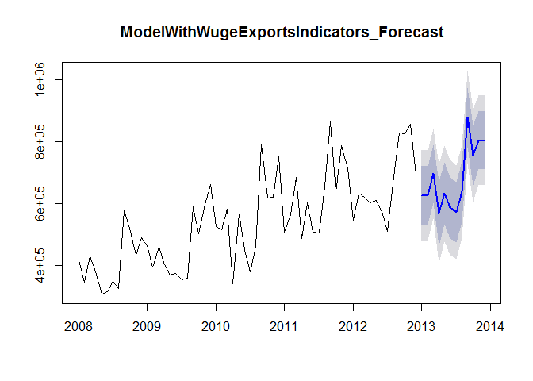

```r
# Add "newdata" to the 2013 indicator values for the forecast.
ModelWithWugeExportsIndicators_Forecast <- forecast(ModelWithWugeExportsIndicators_2012, newdata=data.frame(CEPI_2012=CEPI_2013, UrbanoExports_2012 = UrbanoExports_2013, AEPI_2012 = AEPI_2013, GlobalisationPartyMembers_2012 = GlobalisationPartyMembers_2013),h=12)
ModelWugeWithCEPI_Forecast <- forecast(ModelWugeWithCEPI_2012,newdata=data.frame(CEPI_2012=CEPI_2013), h=12)
ModelWugeWithTrendAndSeasonalityOnly_Forecast <- forecast(ModelWugeWithTrendAndSeasonalityOnly_2012,h=12)

plot(ModelWithWugeExportsIndicators_Forecast, main="ModelWithWugeExportsIndicators_Forecast")
```

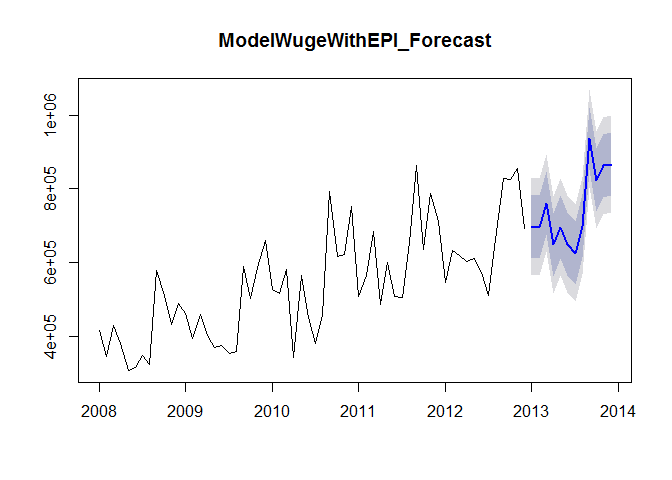

```r
plot(ModelWugeWithCEPI_Forecast, main="ModelWugeWithEPI_Forecast")
```

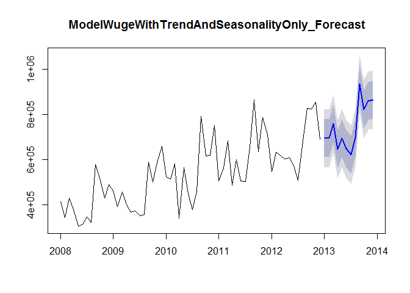

```r
plot(ModelWugeWithTrendAndSeasonalityOnly_Forecast, main="ModelWugeWithTrendAndSeasonalityOnly_Forecast")
```

```r
ModelWithWugeExportsIndicators_Forecast
```

```
##          Point Forecast    Lo 80    Hi 80    Lo 95     Hi 95
## Jan 2013       625378.5 529199.6 721557.4 476353.9  774403.1
## Feb 2013       624914.9 530363.0 719466.9 478411.2  771418.6
## Mar 2013       696227.0 602160.9 790293.0 550476.2  841977.7
## Apr 2013       567366.9 463202.7 671531.1 405969.4  728764.4
## May 2013       632029.3 531460.8 732597.8 476203.2  787855.4
## Jun 2013       585783.0 486374.5 685191.5 431754.3  739811.7
## Jul 2013       571640.8 474032.0 669249.5 420400.7  722880.9
## Aug 2013       638558.7 541541.1 735576.3 488234.5  788882.8
## Sep 2013       878103.3 781975.9 974230.6 729158.5 1027048.0
## Oct 2013       756350.3 658331.3 854369.4 604474.6  908226.1
## Nov 2013       802954.0 709738.0 896169.9 658520.3  947387.6
## Dec 2013       804495.1 710717.6 898272.6 659191.3  949798.9
```

```r
ModelWugeWithCEPI_Forecast
```

```
##          Point Forecast    Lo 80     Hi 80    Lo 95     Hi 95
## Jan 2013       697020.6 612262.9  781778.4 565806.3  828234.9
## Feb 2013       696005.5 611133.0  780878.0 564613.5  827397.5
## Mar 2013       760914.4 675826.6  846002.3 629189.1  892639.8
## Apr 2013       647471.8 563123.9  731819.7 516892.0  778051.6
## May 2013       695969.4 611174.6  780764.3 564697.8  827241.1
## Jun 2013       649848.9 565015.8  734681.9 518518.0  781179.8
## Jul 2013       624883.6 539550.5  710216.7 492778.6  756988.6
## Aug 2013       698337.2 613249.4  783425.1 566611.9  830062.6
## Sep 2013       936673.9 851491.5 1021856.3 804802.2 1068545.6
## Oct 2013       823474.6 738679.8  908269.5 692203.0  954746.3
## Nov 2013       862697.8 777364.7  948030.9 730592.8  994802.8
## Dec 2013       867045.9 781863.5  952228.3 735174.2  998917.6
```

```r
ModelWugeWithTrendAndSeasonalityOnly_Forecast
```

```
##          Point Forecast    Lo 80     Hi 80    Lo 95     Hi 95
## Jan 2013       695728.6 612413.5  779043.8 566781.7  824675.6
## Feb 2013       694583.2 611268.1  777898.4 565636.3  823530.2
## Mar 2013       759275.0 675959.9  842590.2 630328.1  888222.0
## Apr 2013       646831.2 563516.1  730146.4 517884.3  775778.2
## May 2013       694634.0 611318.9  777949.2 565687.1  823581.0
## Jun 2013       648470.0 565154.9  731785.2 519523.1  777417.0
## Jul 2013       623027.0 539711.9  706342.2 494080.1  751974.0
## Aug 2013       696697.8 613382.7  780013.0 567750.9  825644.8
## Sep 2013       934947.6 851632.5 1018262.8 806000.7 1063894.6
## Oct 2013       822139.2 738824.1  905454.4 693192.3  951086.2
## Nov 2013       860841.2 777526.1  944156.4 731894.3  989788.2
## Dec 2013       865319.6 782004.5  948634.8 736372.7  994266.6
```

```r
# In order to be able to correlate the Forecast with the As Is data, it is necessary to convert the Point
# Estimator into a time series.
ModelWithWugeExportsIndicators_Forecast_df <-as.data.frame(ModelWithWugeExportsIndicators_Forecast)
ModelWugeWithCEPI_Forecast_df <-as.data.frame(ModelWugeWithCEPI_Forecast)
ModelWugeWithTrendAndSeasonalityOnly_Forecast_df <-as.data.frame(ModelWugeWithTrendAndSeasonalityOnly_Forecast)
ModelWithWugeExportsIndicators_PointForecast <- ts(ModelWithWugeExportsIndicators_Forecast_df$"Point Forecast", start=c(2013,1), end=c(2013,12), frequency=12)
ModelWugeWithCEPI_PointForecast <- ts(ModelWugeWithCEPI_Forecast_df$"Point Forecast", start=c(2013,1), end=c(2013,12), frequency=12)
ModelWugeWithTrendAndSeasonalityOnly_PointForecast <- ts(ModelWugeWithTrendAndSeasonalityOnly_Forecast_df$"Point Forecast", start=c(2013,1), end=c(2013,12), frequency=12)

# Correlation of the forecasts and As Is data. As a comparison, the correlation of the As Is data for 2013 with the Plan Data.
cor(ModelWithWugeExportsIndicators_PointForecast, WugeAsIs_2013)
```

```
## [1] 0.8187058
```

```r
cor(ModelWugeWithCEPI_PointForecast, WugeAsIs_2013)
```

```
## [1] 0.8392912
```

```r
cor(ModelWugeWithTrendAndSeasonalityOnly_PointForecast, WugeAsIs_2013)
```

```
## [1] 0.8400829
```

```r
cor(WugeAsIs_2013, WugePlan_2013)
```

```
## [1] 0.8143285
```